# **Trabajo Fin de Máster de Patricia Olguín**

## Determinantes y predicción del salario de las mujeres asalariadas en Argentina (2024-2026)

### Una herramienta de referencia salarial validada en el tiempo y comparada con Brasil y España

Máster en Data Science, Big Data & Business Analytics · Universidad Complutense de Madrid

**Pregunta central.** ¿Qué características personales, laborales, del hogar y del territorio se asocian con salarios más altos de las mujeres asalariadas en Argentina, y sirve esa estructura para predecir el salario en el futuro inmediato (un año o menos)? ¿Son esos determinantes propios de Argentina o se repiten en Brasil y España?

**Qué aporta.** La Encuesta Permanente de Hogares (EPH) del INDEC es la fuente más usada para estudiar el mercado de trabajo argentino, pero sus cuadros publicados no responden preguntas como estas:

- ¿cuánto paga el mercado por un perfil concreto, y con qué margen?
- ¿cuánto de la diferencia salarial entre ciudades desaparece al descontar el costo de vida?
- ¿llega la riqueza de Vaca Muerta y de la minería al salario de las mujeres?
- ¿alcanza el salario de una asalariada para sostener a una familia (*welfare ratio* de Allen)?
- ¿cuánto de la brecha de género no se explica por el perfil, y supera el umbral del 5% de la Directiva europea de transparencia retributiva?

Este trabajo aprovecha los microdatos para obtener esa información indirecta y la convierte en una **herramienta de referencia salarial** para empresas y organismos públicos (aplicación Streamlit, sección 10.3).

**Estructura.** La **parte I** estudia a las asalariadas argentinas: construye la base, entrena y valida los modelos fuera de tiempo, interpreta los determinantes y los traduce en la herramienta. La **parte II** repite el análisis con las mismas 13 variables en Brasil y España para distinguir lo que es propio del mercado argentino de lo que es general.

**Datos.** EPH (bases de personas y hogares, 1T2024-1T2026), Canasta Básica Total regional e IPC del INDEC y paridad de poder adquisitivo del Banco Mundial; para la comparación, la PNAD Contínua (IBGE, Brasil) y la Encuesta de Condiciones de Vida y la Encuesta de Estructura Salarial (INE, España). Todos los archivos se leen desde Google Drive.

**Ejecución.** menú *Entorno de ejecución*, opción *Ejecutar todas*. Unos 15 minutos; la primera vez, unos 15 minutos más para preparar las bases de Brasil y España, que quedan guardadas en Drive. No hace falta ninguna clave de GitHub.

**Índice**

**Parte I. Argentina: determinantes del salario de las mujeres y herramienta de referencia**

1. Preparación del entorno
2. Datos: de la encuesta a la base de estudio
3. Depuración de los datos
4. Exploración
5. Modelado predictivo
6. Evaluación en el futuro inmediato y estabilidad
7. ¿Qué determina el salario de las mujeres?
8. Territorio, recursos naturales y poder de compra
9. Brecha de género y transparencia retributiva
10. Del modelo al producto: bandas salariales y aplicación

**Parte II. Argentina frente a Brasil y España**

11. Perspectiva comparada: preparación de las bases, factores que premia cada mercado, brecha y poder de compra

**Conclusiones**

12. Conclusiones generales

# PARTE I. ARGENTINA: DETERMINANTES DEL SALARIO DE LAS MUJERES Y HERRAMIENTA DE REFERENCIA

## 1. Preparación del entorno

### 1.1 Repositorio de GitHub

El notebook clona el repositorio del trabajo, que contiene el archivo de funciones (funciones_tfm.py) y la aplicación. Para **leerlo** no hace falta ninguna clave. Solo la autora, que guarda su token en los *Secretos* de Colab con el nombre GITHUB_TOKEN, sube los resultados a GitHub (secciones 10 y 11).

```python
import os
import subprocess
import sys

USUARIO, REPO = "peolguin", "TFM-Olguin-Patricia"
EN_COLAB = "google.colab" in sys.modules
ruta_repo = f"/content/{REPO}" if EN_COLAB else os.path.abspath(os.environ.get("TFM_REPO", "repo"))

# Token de GitHub: solo existe en la cuenta de la autora
token = None
if EN_COLAB:
    try:
        from google.colab import userdata
        token = userdata.get("GITHUB_TOKEN")
    except Exception:
        print("Sin token de GitHub: el notebook se ejecuta completo, pero no sube resultados al repositorio.")


def git(*args):
    """Ejecuta un comando de git dentro del repositorio."""
    resultado = subprocess.run(["git", *args], cwd=ruta_repo, capture_output=True, text=True)
    print(resultado.stdout.strip() or resultado.stderr.strip())


if EN_COLAB and not os.path.isdir(ruta_repo):
    url = f"https://{USUARIO}:{token}@github.com/{USUARIO}/{REPO}.git" if token else f"https://github.com/{USUARIO}/{REPO}.git"
    subprocess.run(["git", "clone", url, ruta_repo], check=True)
elif EN_COLAB:
    git("pull")


def guardar_en_github(mensaje):
    """Hace el commit de los resultados y los sube a GitHub (solo con el token de la autora)."""
    if EN_COLAB and token:
        git("config", "user.email", "patricia.elizabeth.olguin@gmail.com")
        git("config", "user.name", "Patricia Olguin")
        git("add", ".")
        git("commit", "-m", mensaje)
        git("push", "origin", "main")


os.makedirs(os.path.join(ruta_repo, "modelos"), exist_ok=True)
print("Repositorio listo en", ruta_repo)
```

```
Updating 03ed0f5..20c6c7e
Fast-forward
 README.md                                     |  47 +++--
 app/app.py                                    | 269 +++++++++++++++----------
 notebook/TFM_salarios_mujeres_Argentina.ipynb | 276 +++++++++++++++-----------
 3 files changed, 352 insertions(+), 240 deletions(-)
Repositorio listo en /content/TFM-Olguin-Patricia
```

### 1.2 Drive, librerías y funciones

Como en el módulo de Minería de datos, las funciones auxiliares están en un archivo aparte, funciones_tfm.py, que se importa al inicio.

```python
if EN_COLAB:
    from google.colab import drive
    drive.mount("/content/drive")
    subprocess.run([sys.executable, "-m", "pip", "install", "-q", "mlflow", "shap", "missingno"])

sys.path.append(ruta_repo)
from funciones_tfm import *

import shutil
import warnings

import joblib
import lightgbm as lgb
import missingno as msno
import mlflow
import plotly.graph_objects as go
import statsmodels.formula.api as smf
from IPython.display import Markdown, display
from sklearn.ensemble import RandomForestRegressor
from sklearn.inspection import permutation_importance
from sklearn.linear_model import LassoCV, LinearRegression, RidgeCV
from sklearn.model_selection import GridSearchCV, GroupKFold, cross_val_score
from sklearn.pipeline import make_pipeline
from sklearn.preprocessing import StandardScaler
from sklearn.tree import DecisionTreeRegressor

warnings.filterwarnings("ignore")
sns.set()
pd.set_option("display.max_columns", 60)
pd.set_option("display.width", 180)
```

### 1.3 Archivos de datos

Todos los datos se descargan **una sola vez** de las fuentes oficiales y se guardan en Drive, en la carpeta MyDrive/TFM/ (quien evalúe el trabajo puede agregar a su Drive un acceso directo a la carpeta compartida por la autora):

| Carpeta | Archivo | Fuente |
| --- | --- | --- |
| datos_originales/ | eph_{año}_trim{trimestre}_{pers\|hog}.csv (18 archivos) | INDEC, EPH continua, bases de usuarios |
| datos_originales/ | canasta_basica_regional.csv | INDEC, Canasta Básica Total por región (informes de pobreza) |
| datos_originales/ | ipc_indec.csv | INDEC, IPC nivel general nacional (series de tiempo) |
| datos_originales/ | ppa_banco_mundial.csv | Banco Mundial, PPA del consumo de los hogares (PA.NUS.PRVT.PP) |
| datos_comparacion/pnadc/ | PNADC_{trimestre}{año}.zip (1T2024-2T2026) y Dicionario_e_input.zip | IBGE, PNAD Contínua trimestral |
| datos_comparacion/ecv/ y ees/ | datos_2024.zip, datos_2025.zip; datos_2022.zip | INE, Encuesta de Condiciones de Vida y Encuesta de Estructura Salarial |

Los microdatos de Brasil y España solo se leen la primera vez: la parte II guarda una base común reducida en datos_procesados/ y la reutiliza.

```python
ruta_drive = os.environ.get("TFM_DRIVE", "/content/drive/MyDrive")
ruta_datos = os.path.join(ruta_drive, "TFM", "datos_originales")
ruta_salida = os.path.join(ruta_drive, "TFM", "datos_procesados")
os.makedirs(ruta_salida, exist_ok=True)

# Ondas de la EPH (año, trimestre). Para sumar una onda nueva alcanza con agregarla aquí.
ondas = [(2024, 1), (2024, 2), (2024, 3), (2024, 4), (2025, 1), (2025, 2), (2025, 3), (2025, 4), (2026, 1)]


def ruta_eph(ano, trimestre, tipo):
    return os.path.join(ruta_datos, f"eph_{ano}_trim{trimestre}_{tipo}.csv")


ARCHIVOS = ([ruta_eph(a, t, tipo) for a, t in ondas for tipo in ("pers", "hog")]
            + [os.path.join(ruta_datos, f) for f in ("canasta_basica_regional.csv", "ipc_indec.csv", "ppa_banco_mundial.csv")])
faltan = [f for f in ARCHIVOS if not os.path.isfile(f)]
if faltan:
    raise FileNotFoundError("Faltan archivos en Drive:\n" + "\n".join(faltan))
ruta_comparacion = os.path.join(ruta_drive, "TFM", "datos_comparacion")
ruta_base_comun = os.path.join(ruta_salida, "base_comun_BR_ES.parquet")
ruta_validacion_ees = os.path.join(ruta_salida, "validacion_EES.csv")
HAY_COMPARACION = os.path.isfile(ruta_base_comun)
print(f"{len(ARCHIVOS)} archivos de la parte I disponibles | base común de Brasil y España: "
      f"{'ya preparada' if HAY_COMPARACION else 'se prepara en la sección 11.1'}")
```

```
21 archivos de la parte I disponibles | base común de Brasil y España: ya preparada
```

## 2. Datos: de la encuesta a la base de estudio

### 2.1 Lectura de las bases de personas y hogares

```python
personas = {(a, t): leer_eph(ruta_eph(a, t, "pers")) for a, t in ondas}
hogares = {(a, t): leer_eph(ruta_eph(a, t, "hog")) for a, t in ondas}
clave_hogar = ["CODUSU", "NRO_HOGAR"]

# Tamaño de cada onda y controles de integridad
pd.DataFrame([{"onda": f"{t}T{a}", "personas": personas[(a, t)].shape[0], "columnas personas": personas[(a, t)].shape[1],
               "hogares": hogares[(a, t)].shape[0], "columnas hogares": hogares[(a, t)].shape[1],
               "duplicados": personas[(a, t)].duplicated(clave_hogar + ["COMPONENTE"]).sum(),
               "personas sin hogar": (~personas[(a, t)].set_index(clave_hogar).index.isin(
                   hogares[(a, t)].set_index(clave_hogar).index)).sum()} for a, t in ondas])
```

|  | onda | personas | columnas personas | hogares | columnas hogares | duplicados | personas sin hogar |
| --- | --- | --- | --- | --- | --- | --- | --- |
| 0 | 1T2024 | 46050 | 235 | 16104 | 98 | 0 | 0 |
| 1 | 2T2024 | 47151 | 235 | 16453 | 98 | 0 | 0 |
| 2 | 3T2024 | 47564 | 235 | 16650 | 98 | 0 | 0 |
| 3 | 4T2024 | 46860 | 235 | 16511 | 98 | 0 | 0 |
| 4 | 1T2025 | 45425 | 235 | 15984 | 98 | 0 | 0 |
| 5 | 2T2025 | 46086 | 235 | 16169 | 98 | 0 | 0 |
| 6 | 3T2025 | 44946 | 235 | 15860 | 98 | 0 | 0 |
| 7 | 4T2025 | 43703 | 235 | 15534 | 98 | 0 | 0 |
| 8 | 1T2026 | 43739 | 234 | 15447 | 98 | 0 | 0 |

### 2.2 Construcción de la base de estudio

Antes de filtrar usamos la base de personas **completa** (todos los miembros de cada hogar) para construir variables que la EPH no pregunta a la trabajadora (función variables_del_hogar):

- **Hijos propios:** la EPH solo registra el parentesco de cada miembro con el jefe o la jefa del hogar. Si la trabajadora es jefa o cónyuge, sus hijos son los miembros registrados como hijos; si es hija o nuera, se aproximan por los nietos del jefe.
- **Educación de la pareja, si está ocupada y clima educativo del hogar** (años de educación de los otros adultos, un proxy del origen social).
- **Composición del hogar:** menores, mayores y otros ocupados.

Luego nos quedamos con la **población de estudio**: asalariados ocupados de 18 a 60 años con salario (P21 > 0), ponderador de ingresos (PONDIIO > 0) y horas válidas. Los varones se conservan solo para medir la brecha de género (sección 9). También guardamos a **todas** las mujeres de 18 a 60 años, trabajen o no (sección 7.3).

```python
bases, poblacion = [], []
for a, t in ondas:
    base_onda, mujeres_onda = procesar_onda(personas[(a, t)], hogares[(a, t)], a, t, clave_hogar)
    bases.append(base_onda)
    poblacion.append(mujeres_onda)
base = pd.concat(bases, ignore_index=True).drop(columns=["CAT_INAC"], errors="ignore")
POBLACION_FEMENINA = pd.concat(poblacion, ignore_index=True)
del personas, hogares, bases
print(f"Base de estudio: {base.shape[0]:,} asalariados y {base.shape[1]} columnas")
base.groupby(["ANO4", "TRIMESTRE", "CH04"]).size().unstack().rename(columns={1: "varones", 2: "mujeres"}).T
```

```
Base de estudio: 96,844 asalariados y 319 columnas
```

| ANO4 TRIMESTRE CH04 | 2024 1 | 2024 2 | 2024 3 | 2024 4 | 2025 1 | 2025 2 | 2025 3 | 2025 4 | 2026 1 |
| --- | --- | --- | --- | --- | --- | --- | --- | --- | --- |
| varones | 5723 | 5980 | 5883 | 5926 | 5470 | 5822 | 5563 | 5373 | 5131 |
| mujeres | 4941 | 5556 | 5474 | 5468 | 4644 | 5324 | 5054 | 5046 | 4466 |

### 2.3 Variable objetivo

- **Salario horario** = P21 / (PP3E_TOT × 4,3 semanas). Usamos el salario *por hora* para comparar jornadas distintas: las mujeres trabajan más a tiempo parcial por las tareas de cuidado no remuneradas.
- **Relativo:** lo dividimos por la **mediana ponderada** del salario horario de todos los asalariados del trimestre. Así se neutralizan la inflación, la estacionalidad y la volatilidad macroeconómica sin necesidad de deflactar.
- **Variable objetivo:** y = log(salario horario / mediana del trimestre). y = 0 es cobrar la mediana; y = 0,10, cobrar alrededor de un 10% más.

Antes de calcular la mediana eliminamos el 0,5% superior e inferior del salario horario de cada trimestre, que suelen ser errores de declaración.

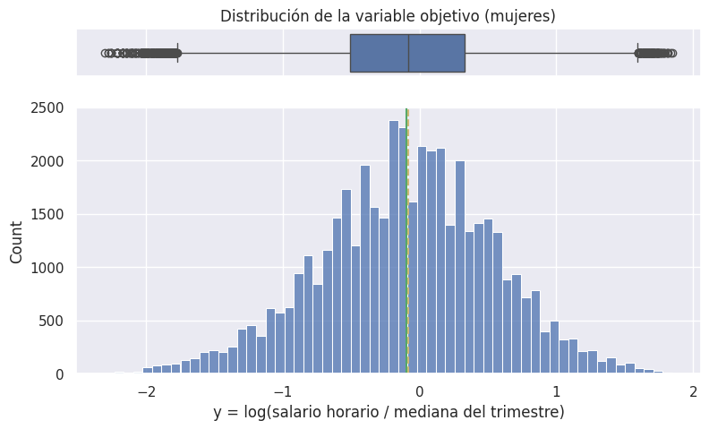

| periodo | 20241 | 20242 | 20243 | 20244 | 20251 | 20252 | 20253 | 20254 | 20261 |
| --- | --- | --- | --- | --- | --- | --- | --- | --- | --- |
| mediana del salario horario ($) | 1744.0 | 2658.0 | 3391.0 | 3876.0 | 4374.0 | 4845.0 | 5168.0 | 5651.0 | 5814.0 |
| variación trimestral (%) | NaN | 52.4 | 27.6 | 14.3 | 12.9 | 10.8 | 6.7 | 9.4 | 2.9 |

```python
base["periodo"] = base["ANO4"] * 10 + base["TRIMESTRE"]                 # 20241 ... 20261
base["t"] = (base["ANO4"] - 2024) * 4 + base["TRIMESTRE"] - 1            # 0 ... 8
base["id_hogar"] = base["CODUSU"] + "_" + base["NRO_HOGAR"].astype(str)
base["id_persona"] = base["id_hogar"] + "_" + base["COMPONENTE"].astype(str)

# Salario horario y recorte de valores extremos por trimestre
base["salario_horario"] = base["P21"] / (base["PP3E_TOT"] * 4.3)
limites = base.groupby("periodo")["salario_horario"].quantile([0.005, 0.995]).unstack()
base = base[base["salario_horario"].between(base["periodo"].map(limites[0.005]),
                                            base["periodo"].map(limites[0.995]))].reset_index(drop=True)

# Mediana ponderada de cada trimestre y variable objetivo
mediana_trimestre = base.groupby("periodo").apply(lambda g: mediana_ponderada(g["salario_horario"], g["PONDIIO"]))
base["mediana_trimestre"] = base["periodo"].map(mediana_trimestre)
base["y"] = np.log(base["salario_horario"] / base["mediana_trimestre"])
es_mujer = base["CH04"] == 2
histogram_boxplot(base.loc[es_mujer, "y"], xlabel="y = log(salario horario / mediana del trimestre)",
                  title="Distribución de la variable objetivo (mujeres)")
pd.DataFrame({"mediana del salario horario ($)": mediana_trimestre.round(0),
              "variación trimestral (%)": (100 * mediana_trimestre.pct_change()).round(1)}).T
```

**Comentarios**

La base de estudio reúne unos 97.000 registros de asalariados, 46.000 de ellos de mujeres (unas 5.000 por trimestre). La mediana nominal del salario horario se multiplicó por más de tres en el período, con subas trimestrales que bajaron del 52% al 3%. La variable objetivo relativa elimina ese efecto: lo que se modela es la **posición** de cada trabajadora en la distribución salarial de su trimestre. Su distribución es aproximadamente simétrica y centrada algo por debajo de 0 (las mujeres cobran por hora un poco menos que la mediana de todos los asalariados).

A partir de aquí las **decisiones** de depuración se toman solo con los datos de las mujeres; las transformaciones se aplican también a los varones.

## 3. Depuración de los datos

### 3.1 Selección inicial de variables (criterio conceptual)

De las más de 300 columnas excluimos, con un motivo explícito, las que no pueden usarse para explicar el salario:

| Grupo excluido | Motivo |
| --- | --- |
| Identificación, control técnico y ponderadores | No describen a la persona |
| Definen la población o la variable objetivo | Son constantes tras el filtro, o construyen el salario horario |
| Ingresos que contienen el salario | Deciles e ingresos individuales y familiares: usarlos sería **fuga de información** |
| Montos de otros ingresos, texto libre | Son montos o descripciones abiertas; la información está en otras variables |
| Preguntas que no corresponden a asalariadas | Módulos de desocupados, inactivos e independientes |

```python
mujeres = base[es_mujer]
EXCLUSION = {
    "Identificación, control técnico y ponderadores": ["CODUSU", "NRO_HOGAR", "COMPONENTE", "H15", "REALIZADA", "IMPUTA",
                                                       "ANO4", "TRIMESTRE", "PONDERA", "PONDII", "PONDIH", "PONDIIO"],
    "Definen la población o la variable objetivo": ["CH04", "ESTADO", "CAT_OCUP", "P21", "PP3E_TOT"],
    "Ingresos que contienen el salario": [c for c in mujeres.columns if re.search(r"DEC|^P47T$|^ITF$|^IPCF$|^PP08", c)],
    "Montos de otros ingresos, texto libre": ["TOT_P12", "T_VI", "PP06C", "PP06D", "CH05", "CH15_COD", "CH16_COD"]
                                             + [c for c in mujeres.columns if re.fullmatch(r"V\d+_(\d+_)?A?M", c) or c.endswith("_ESP")],
    "Preguntas que no corresponden a asalariadas": [c for c in mujeres.columns if re.match(r"PP0?(2|5|6|10|11)[A-Z_]", c)],
}
AUXILIARES = ["periodo", "t", "id_hogar", "id_persona", "salario_horario", "mediana_trimestre", "y"]
CONSTRUIDAS_HOGAR = ["menores_6", "menores_18", "mayores_65", "ocupados_hogar", "mujeres_adultas_hogar",
                     "hijos_propios_menores_6", "hijos_propios_menores_18", "educ_pareja", "pareja_ocupada", "clima_educativo"]

# Tabla de decisiones: cada variable con su base de origen y el motivo de exclusión
motivo = {v: grupo for grupo, vs in EXCLUSION.items() for v in vs if v in mujeres.columns}
diccionario = pd.DataFrame({"variable": [c for c in mujeres.columns if c not in AUXILIARES]})
diccionario["base"] = np.where(diccionario.variable.isin(CONSTRUIDAS_HOGAR), "Construida",
                               np.where(diccionario.variable.str.match(r"^(IV|II|V\d|IX|VII)"), "Hogares", "Personas"))
diccionario["motivo de exclusión"] = diccionario.variable.map(motivo).fillna("candidata")
candidatas = diccionario.loc[~diccionario.variable.isin(motivo), "variable"].tolist()
print(f"Variables: {len(diccionario)} | candidatas: {len(candidatas)}")
diccionario.groupby(["motivo de exclusión", "base"]).size().unstack(fill_value=0)
```

```
Variables: 319 | candidatas: 148
```

| base motivo de exclusión | Construida | Hogares | Personas |
| --- | --- | --- | --- |
| Definen la población o la variable objetivo | 0 | 0 | 5 |
| Identificación, control técnico y ponderadores | 0 | 0 | 12 |
| Ingresos que contienen el salario | 0 | 0 | 44 |
| Montos de otros ingresos, texto libre | 0 | 27 | 7 |
| Preguntas que no corresponden a asalariadas | 0 | 0 | 76 |
| candidata | 10 | 69 | 69 |

### 3.2 Códigos "no sabe / no responde" y preguntas que no aplican

Según el diseño de registros, los códigos 9 y 99 son "no sabe / no responde" salvo en las variables donde son valores válidos (conteos, edad, aglomerado, techo de la vivienda). Los convertimos en nulos. Luego eliminamos las candidatas con más del 90% de sus valores en "no corresponde" (0) o nulos: son preguntas dirigidas a subgrupos muy pequeños.

```python
df = base[candidatas + AUXILIARES + ["PONDIIO", "CH04", "ANO4", "TRIMESTRE", "COMPONENTE", "PP3E_TOT"]].copy()
m = es_mujer          # máscara de mujeres: las decisiones se toman con ellas

CONTEOS = ["CH06", "IV2", "II1", "II2", "II3_1", "II5_1", "II6_1", "IX_TOT", "IX_MEN10", "IX_MAYEQ10", "PP03D",
           "PP3F_TOT", "PP04B2", "PP04B3_MES", "PP04B3_ANO", "PP04B3_DIA"] + CONSTRUIDAS_HOGAR
SIN_CODIGO_NSNR = CONTEOS + ["AGLOMERADO", "REGION", "IV4", "PP04B_COD", "PP04D_COD", "VII1_1", "VII1_2", "VII2_1",
                             "VII2_2", "VII2_3", "VII2_4", "MAS_500", "CH03", "PP04G"]
for col in candidatas:
    if col not in SIN_CODIGO_NSNR and pd.api.types.is_numeric_dtype(df[col]):
        df[col] = df[col].replace(9 if df[col].max() <= 9 else 99, np.nan)
df["CH14"] = df["CH14"].replace([98, 99], np.nan)
df["PP3F_TOT"] = df["PP3F_TOT"].replace(999, np.nan)
for col in ["IV2", "II1", "II2", "IX_TOT"]:
    df[col] = df[col].replace(99, np.nan)

no_aplica = pd.Series({c: ((df.loc[m, c] == 0) | df.loc[m, c].isna()).mean() for c in candidatas
                       if pd.api.types.is_numeric_dtype(df[c]) and c not in CONTEOS})
candidatas = [c for c in candidatas if c not in no_aplica[no_aplica > 0.90].index]
print(f"Eliminadas por no aplicar a las asalariadas: {(no_aplica > 0.90).sum()} | candidatas: {len(candidatas)}")
```

```
Eliminadas por no aplicar a las asalariadas: 8 | candidatas: 140
```

### 3.3 Ingeniería de variables

Con la función crear_variables construimos variables más informativas y reducimos la cardinalidad de los códigos largos: años de educación y **experiencia potencial** de Mincer (edad − educación − 6); carácter, jerarquía, tecnología y calificación de la ocupación (CNO-2001); actividad a 2 dígitos y rama (CAES-Mercosur); tamaño del establecimiento; antigüedad; jornada parcial (< 35 horas); hacinamiento y organización de las tareas domésticas.

```python
df = crear_variables(df)
REEMPLAZADAS = ["CH03", "CH06", "CH07", "CH08", "CH12", "CH13", "CH14", "CH15", "CH16", "NIVEL_ED", "PP04A", "PP04B_COD",
                "PP04D_COD", "PP04C", "PP04C99", "PP04G", "PP07A", "PP04B3_MES", "PP04B3_ANO", "PP04B3_DIA", "VII1_1",
                "VII1_2", "VII2_1", "VII2_2", "VII2_3", "VII2_4", "ocupados_hogar", "mujeres_adultas_hogar"]
NUEVAS = ["edad", "anios_educ", "exp_pot", "exp_pot2", "parentesco", "estado_civil", "cobertura_salud",
          "lugar_nacimiento", "residencia_5_anios", "cno_caracter", "cno_jerarquia", "cno_tecnologia", "calificacion",
          "caes_division", "rama", "tamano_establecimiento", "sector", "lugar_trabajo", "antiguedad", "jornada_parcial",
          "hacinamiento", "otros_ocupados_hogar", "otras_mujeres_adultas", "realiza_tareas_casa",
          "servicio_domestico_hogar", "recibe_ayuda_tareas"]
candidatas = [c for c in candidatas if c not in REEMPLAZADAS] + NUEVAS
print(f"Variables candidatas tras la ingeniería: {len(candidatas)}")
```

```
Variables candidatas tras la ingeniería: 141
```

### 3.4 Tipos, categorías poco frecuentes y variables redundantes

- Las preguntas sí/no (1 = sí, 2 = no) pasan a 1/0; el resto de los códigos numéricos que representan categorías se tratan como **categóricos** (el código 3 no es "el triple" del código 1).
- Eliminamos las variables casi constantes (> 98% en un valor) y las que tienen más del 40% de nulos, salvo las de la pareja y el clima educativo, cuyo nulo es **estructural** (no tiene pareja o no convive con otros adultos).
- Unimos en "Otros" las categorías con menos de 100 casos.
- Si un par de variables tiene una asociación mayor a 0,90 (correlación de Pearson entre numéricas, V de Cramér entre categóricas), conservamos la más interpretable.

```python
binarias, categoricas_codigo = [], []
for col in candidatas:
    if not pd.api.types.is_numeric_dtype(df[col]) or col in CONTEOS or col in NUEVAS:
        continue
    valores = set(df[col].dropna().unique())
    if valores <= {0, 1, 2} and {1, 2} <= valores:
        df[col] = df[col].map({1: 1.0, 2: 0.0})
        binarias.append(col)
    elif valores <= {0, 1}:
        binarias.append(col)
    elif valores <= {0, 5}:                              # PP07G_59: 5 = "no tiene ningún beneficio"
        df[col] = (df[col] == 5).astype(float)
        binarias.append(col)
    else:
        categoricas_codigo.append(col)
for col in categoricas_codigo:
    df[col] = df[col].map(lambda v: f"código {int(v)}" if pd.notna(v) else np.nan)

# Variables con poca información (el nulo de la pareja y del clima educativo es estructural)
NULO_ESTRUCTURAL = ["educ_pareja", "pareja_ocupada", "clima_educativo"]
pct_moda = pd.Series({c: df.loc[m, c].value_counts(normalize=True, dropna=False).iloc[0] for c in candidatas})
pct_nulos = df.loc[m, candidatas].isna().mean()
poca_informacion = pct_moda[pct_moda > 0.98].index.tolist() + [c for c in pct_nulos[pct_nulos > 0.40].index
                                                                if c not in NULO_ESTRUCTURAL]
candidatas = [c for c in candidatas if c not in poca_informacion]
CATEGORICAS = [c for c in candidatas if not pd.api.types.is_numeric_dtype(df[c])]
NUMERICAS = [c for c in candidatas if c not in CATEGORICAS]

# Categorías poco frecuentes
for col in CATEGORICAS:
    conteo = df.loc[m, col].value_counts()
    df[col] = df[col].where(~df[col].isin(conteo[conteo < 100].index), "Otros")

# Variables redundantes
pares = []
corr = df.loc[m, NUMERICAS].corr().abs()
for i, a in enumerate(NUMERICAS):
    pares += [(a, b, corr.loc[a, b]) for b in NUMERICAS[i + 1:] if corr.loc[a, b] > 0.90]
for i, a in enumerate(CATEGORICAS):
    for b in CATEGORICAS[i + 1:]:
        v = cramers_v(df.loc[m, a].fillna("sin dato"), df.loc[m, b].fillna("sin dato"))
        if v > 0.90:
            pares.append((a, b, v))
CONSERVAR_SIEMPRE = {"exp_pot", "exp_pot2", "rama", "caes_division", "AGLOMERADO", "anios_educ", "PP07H", "IV2", "IX_TOT",
                     "hijos_propios_menores_6", "hijos_propios_menores_18", "educ_pareja"}
redundantes = []
for a, b, _ in pares:
    if a in redundantes or b in redundantes or (a in CONSERVAR_SIEMPRE and b in CONSERVAR_SIEMPRE):
        continue
    redundantes.append(a if b in CONSERVAR_SIEMPRE else b)
candidatas = [c for c in candidatas if c not in redundantes]
CATEGORICAS = [c for c in CATEGORICAS if c in candidatas]
NUMERICAS = [c for c in NUMERICAS if c in candidatas]
print("Poca información:", poca_informacion)
print("Redundantes:", redundantes)
print(f"Variables candidatas finales: {len(candidatas)} ({len(NUMERICAS)} numéricas o binarias y {len(CATEGORICAS)} categóricas)")
```

```
Poca información: ['CH09', 'PP07F2', 'PP07F1_2', 'PP07F1_3', 'IV6', 'IV8', 'IV12_3', 'II5_1', 'II6_1', 'II9', 'V1', 'V21_01', 'V3', 'V4', 'V5_03', 'V8', 'V9', 'V10', 'V11_02', 'V18', 'V19_A', 'V19_B', 'V21_02', 'V21_03', 'CH11', 'PP07I', 'PP09B', 'PP07I2', 'V2_02', 'V2_03', 'V2_01']
Redundantes: ['PP03D', 'PP07G2', 'PP07G3', 'PP07G4', 'PP07G_59', 'PP07G1', 'EMPLEO', 'II1', 'II3_1', 'IX_MAYEQ10', 'edad', 'REGION', 'MAS_500']
Variables candidatas finales: 97 (62 numéricas o binarias y 35 categóricas)
```

**Comentarios**

- **Formalidad:** el descuento jubilatorio (PP07H), las vacaciones, el aguinaldo, la obra social y la variable EMPLEO miden casi lo mismo; conservamos PP07H, la definición habitual de empleo registrado.
- **Edad y experiencia:** con edad, educación y experiencia juntas la regresión tendría colinealidad perfecta; conservamos la experiencia y su cuadrado, que la ecuación de Mincer requiere.
- **Territorio:** la región y el tamaño del aglomerado están contenidos en el aglomerado.

### 3.5 Valores atípicos y perdidos

**Atípicos.** Medimos su incidencia con los criterios del módulo de Minería de datos y los gestionamos con **winsorización**: los valores fuera de los percentiles 1 y 99 se reemplazan por esos límites, calculados **solo con el período de entrenamiento** para no usar información del futuro.

```python
continuas = [c for c in NUMERICAS if c not in binarias and df[c].nunique() > 10]
incidencia = df.loc[m, continuas].apply(incidencia_outliers).T
incidencia.insert(0, "asimetría", df.loc[m, continuas].skew())
en_entrenamiento = m & (df["t"] <= 5)
for col in continuas:
    df[col] = df[col].clip(df.loc[en_entrenamiento, col].quantile(0.01), df.loc[en_entrenamiento, col].quantile(0.99))
incidencia.round(2)
```

|  | asimetría | % atípicos inferiores | % atípicos superiores |
| --- | --- | --- | --- |
| PP3F_TOT | 3.79 | 0.00 | 15.70 |
| PP04B2 | 5.86 | 0.00 | 20.15 |
| menores_18 | 1.50 | 0.00 | 0.03 |
| educ_pareja | -0.38 | 0.00 | 0.00 |
| clima_educativo | -0.44 | 0.00 | 0.00 |
| hijos_propios_menores_18 | 1.57 | 0.00 | 0.46 |
| IX_TOT | 1.39 | 0.00 | 0.55 |
| anios_educ | -0.62 | 0.47 | 0.00 |
| exp_pot | 0.19 | 0.00 | 0.00 |
| exp_pot2 | 1.06 | 0.00 | 0.00 |
| hacinamiento | 2.08 | 0.00 | 1.09 |

**Perdidos.** Medimos el porcentaje de nulos por variable y si aparecen juntos (paquete missingno).

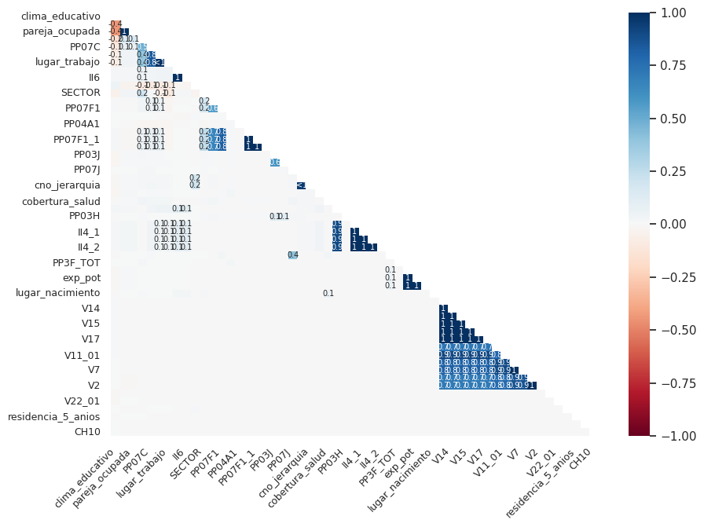

|  | clima_educativo | educ_pareja | pareja_ocupada | PP07L | PP07C | PP07B1_01 | lugar_trabajo | II5 | II6 | cno_tecnologia | SECTOR |
| --- | --- | --- | --- | --- | --- | --- | --- | --- | --- | --- | --- |
| % de nulos | 59.9 | 56.6 | 56.5 | 39.0 | 26.5 | 20.4 | 20.2 | 6.4 | 6.4 | 3.0 | 2.9 |

```python
perdidos = (100 * df.loc[m, candidatas].isna().mean()).sort_values(ascending=False)
con_nulos = perdidos[perdidos > 0].index.tolist()
msno.heatmap(df.loc[m, con_nulos], figsize=(10, 7), fontsize=9)
plt.show()
perdidos[perdidos > 1].round(1).to_frame("% de nulos").T
```

**Justificación**

- **Atípicos:** la incidencia es muy baja (menos del 1,1%) salvo en las horas en otras ocupaciones y las casas en que trabaja el servicio doméstico, donde la mayoría tiene 0 y cualquier valor positivo aparece como "atípico"; no son errores. La winsorización conserva todas las observaciones y evita que unos pocos casos dominen la regresión lineal.
- **Perdidos:** casi todos son **estructurales**. La educación y la ocupación de la pareja (57%) faltan cuando la mujer no convive en pareja (el mapa de calor muestra que aparecen siempre juntas) y el clima educativo cuando no hay otros adultos. Eliminar los registros con nulos haría perder a casi todas las mujeres sin pareja. Por eso imputamos en la sección 5, después de separar los conjuntos: las numéricas con la mediana del entrenamiento y un **indicador** (_faltante) que conserva la información de *por qué* falta el dato; las categóricas, con "Sin dato".

### 3.6 Diccionario de variables

Cada variable candidata tiene una descripción y un **bloque temático** (definidos en funciones_tfm.py). Los bloques distinguen los factores **accionables** (que la persona o la empresa pueden modificar) de los **estructurales** (terreno de la política pública).

```python
diccionario_final = pd.DataFrame({"variable": candidatas})
diccionario_final["descripción"] = diccionario_final.variable.map(DESCRIPCION).fillna(diccionario_final.variable)
diccionario_final["bloque"] = diccionario_final.variable.map(bloque_de)
diccionario_final["carácter"] = diccionario_final.bloque.map(CARACTER)
diccionario_final["tipo"] = np.where(diccionario_final.variable.isin(CATEGORICAS), "categórica",
                                     np.where(diccionario_final.variable.isin(binarias), "binaria (1 = sí)", "numérica"))
diccionario_final.to_csv(os.path.join(ruta_repo, "modelos", "diccionario_variables.csv"), index=False)
diccionario_final.groupby(["carácter", "bloque"]).size().to_frame("variables")
```

| carácter | bloque | variables |
| --- | --- | --- |
| Accionable (empresa y política laboral) | Condiciones de trabajo | 22 |
| Accionable (empresa) | Ocupación y empresa | 13 |
| Accionable (persona) | Capital humano | 5 |
| Estructural (política pública) | Estrategias del hogar | 15 |
|  | Hogar y cuidados | 18 |
|  | Territorio y migración | 3 |
|  | Vivienda y hábitat | 21 |

## 4. Exploración

Antes de modelar miramos cómo se relacionan con el salario relativo algunas variables centrales y dónde trabajan las asalariadas.

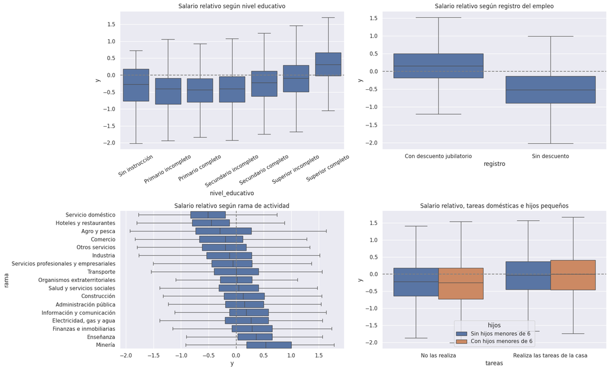

```python
dm = df[m].copy()
orden_ed = ["Sin instrucción", "Primario incompleto", "Primario completo", "Secundario incompleto",
            "Secundario completo", "Superior incompleto", "Superior completo"]
fig, axs = plt.subplots(2, 2, figsize=(18, 11))
sns.boxplot(data=dm, x="nivel_educativo", y="y", order=orden_ed, ax=axs[0, 0], showfliers=False)
axs[0, 0].set_title("Salario relativo según nivel educativo")
axs[0, 0].tick_params(axis="x", rotation=30)
sns.boxplot(data=dm.assign(registro=dm["PP07H"].map({1: "Con descuento jubilatorio", 0: "Sin descuento"})),
            x="registro", y="y", ax=axs[0, 1], showfliers=False)
axs[0, 1].set_title("Salario relativo según registro del empleo")
orden_rama = dm.groupby("rama")["y"].median().sort_values().index
sns.boxplot(data=dm, y="rama", x="y", order=orden_rama, ax=axs[1, 0], showfliers=False)
axs[1, 0].set_title("Salario relativo según rama de actividad")
sns.boxplot(data=dm.assign(tareas=dm["realiza_tareas_casa"].map({1: "Realiza las tareas de la casa", 0: "No las realiza"}),
                           hijos=np.where(dm["hijos_propios_menores_6"] > 0, "Con hijos menores de 6", "Sin hijos menores de 6")),
            x="tareas", y="y", hue="hijos", ax=axs[1, 1], showfliers=False)
axs[1, 1].set_title("Salario relativo, tareas domésticas e hijos pequeños")
for ax in axs.flat:
    ax.axhline(0, ls="--", c="grey") if ax != axs[1, 0] else ax.axvline(0, ls="--", c="grey")
plt.tight_layout()
plt.show()
```

```python
# ¿Dónde trabajan las asalariadas? Treemap por rama y calificación (módulo de Visualización avanzada)
# Primer nivel: ramas; al hacer clic en una rama se abre su composición por calificación.
peso_rama = dm.dropna(subset=["rama"]).groupby(["rama", "calificacion"], dropna=False)["PONDIIO"].sum().reset_index()
peso_rama["calificacion"] = peso_rama["calificacion"].fillna("Sin dato")
# Las ramas con menos del 4% del empleo se agrupan en "Otras ramas" para que todas las etiquetas se lean
cuota = peso_rama.groupby("rama")["PONDIIO"].transform("sum") / peso_rama["PONDIIO"].sum()
peso_rama.loc[cuota < 0.04, "rama"] = "Otras ramas"
peso_rama = peso_rama.groupby(["rama", "calificacion"], as_index=False)["PONDIIO"].sum()
peso_rama["rama"] = peso_rama["rama"].str.replace(" y ", " y<br>", n=1, regex=False)   # etiquetas en dos líneas
fig = px.treemap(peso_rama, path=[px.Constant("Asalariadas"), "rama", "calificacion"], values="PONDIIO", maxdepth=2,
                 color="rama", color_discrete_sequence=["#264653", "#2a9d8f", "#e9c46a", "#f4a261", "#e76f51", "#457b9d",
                                                         "#6a994e", "#b5838d", "#bc6c25", "#8d99ae", "#9c6644"],
                 title="Empleo asalariado femenino por rama de actividad (1T2024-1T2026)<br>"
                       "<sup>Haga clic en una rama para ver su composición por calificación</sup>", height=600)
fig.update_traces(texttemplate="<b>%{label}</b><br>%{percentRoot:.0%}", textfont_size=13,
                  hovertemplate="<b>%{label}</b><br>%{percentRoot:.1%} de las asalariadas<extra></extra>",
                  marker=dict(line=dict(color="white", width=2)), root_color="#eef5f4")
fig.update_layout(uniformtext=dict(minsize=11, mode="hide"), margin=dict(t=80, l=10, r=10, b=10))
fig.show()
```

[interactive chart not shown]

**Ranking de variables con la V de Cramér.** Como en la tarea de Minería de datos, agregamos dos variables **aleatorias de control**: las que quedan por debajo de ellas no tienen relación con el salario.

```python
rng = np.random.default_rng(SEMILLA)
dm["aleatorio"], dm["aleatorio2"] = rng.uniform(0, 1, len(dm)), rng.uniform(0, 1, len(dm))
tablaCramer = pd.DataFrame(dm[candidatas + ["aleatorio", "aleatorio2"]].apply(lambda x: cramers_v(x, dm["y"])),
                           columns=["VCramer"])
tablaCramer["descripción"] = [DESCRIPCION.get(v, v) for v in tablaCramer.index]
fig = px.bar(tablaCramer.sort_values("VCramer").tail(30), x="VCramer", y="descripción", height=750,
             title="Relación de cada variable con el salario relativo (V de Cramér, 30 más altas)")
fig.show()
umbral = tablaCramer.loc[["aleatorio", "aleatorio2"], "VCramer"].max()
print("Variables por debajo de los aleatorios de control:", tablaCramer[tablaCramer.VCramer <= umbral].index.tolist())
```

[interactive chart not shown]

```
Variables por debajo de los aleatorios de control: ['aleatorio', 'aleatorio2']
```

**Observaciones**

- El salario relativo sube con el nivel educativo; el salto mayor es el del superior completo. El empleo registrado se asocia con salarios horarios claramente más altos.
- El empleo femenino se concentra en enseñanza, salud, comercio y servicio doméstico, ramas con niveles salariales muy distintos: el servicio doméstico está en el extremo inferior.
- La relación con las tareas domésticas y los hijos pequeños es débil a simple vista; la sección 7.3 muestra que el costo de los cuidados no aparece en el salario *por hora* sino en las horas y en la decisión de trabajar.
- La V de Cramér ubica arriba a la **formalidad**, el **servicio doméstico** y la **ocupación y actividad**. Todas las candidatas superan a los aleatorios de control. Como es una medida univariante (no tiene en cuenta que muchas variables dicen lo mismo), la selección final se hace con los modelos.

## 5. Modelado predictivo

### 5.1 Partición temporal, imputación y codificación

La pregunta del trabajo es si los determinantes sirven para **predecir el futuro inmediato**, por eso los conjuntos se separan **por tiempo** y no al azar:

| Conjunto | Ondas | Uso |
| --- | --- | --- |
| Entrenamiento | 1T2024 a 2T2025 (6 trimestres) | Ajustar los modelos |
| Validación | 3T2025 a 4T2025 (2 trimestres) | Comparar modelos, elegir variables e hiperparámetros, calibrar las bandas |
| Prueba | 1T2026 | Evaluación final con datos que ningún modelo vio |

Una partición al azar mezclaría trimestres y, por el panel rotativo de la EPH (cada hogar se encuesta hasta cuatro veces), pondría a la misma mujer en entrenamiento y en prueba: el resultado sería optimista. Por eso informamos también el resultado para las mujeres "nuevas" del 1T2026.

```python
entrenamiento = m & (df["t"] <= 5)
validacion = m & df["t"].isin([6, 7])
prueba = m & (df["t"] == 8)
prueba_nuevas = prueba & ~df["id_persona"].isin(set(df.loc[m & (df["t"] <= 7), "id_persona"]))

# Imputación con la mediana del entrenamiento (+ indicador) y "Sin dato" en las categóricas
for col in NUMERICAS:
    faltantes = df[col].isna()
    if faltantes[m].mean() > 0.01:
        df[f"{col}_faltante"] = faltantes.astype(float)
    df[col] = df[col].fillna(df.loc[entrenamiento, col].median())
for col in CATEGORICAS:
    df[col] = df[col].fillna("Sin dato").astype(str)
INDICADORES = [c for c in df.columns if c.endswith("_faltante")]
VARIABLES = NUMERICAS + INDICADORES + CATEGORICAS

# One-Hot Encoding para los modelos lineales y el Random Forest; LightGBM usa las categorías de forma nativa
X_onehot = one_hot(df[VARIABLES], CATEGORICAS)
X_cat = df[VARIABLES].copy()
for col in CATEGORICAS:
    X_cat[col] = pd.Categorical(X_cat[col], categories=sorted(df.loc[m, col].unique()))
y, w, grupos = df["y"], df["PONDIIO"], df["id_hogar"]
Xtr_oh, ytr, wtr = X_onehot[entrenamiento], y[entrenamiento], w[entrenamiento]
Xva_oh, yva, wva = X_onehot[validacion], y[validacion], w[validacion]
Xtr_cat, Xva_cat = X_cat[entrenamiento], X_cat[validacion]

pd.DataFrame({"registros": [entrenamiento.sum(), validacion.sum(), prueba.sum(), prueba_nuevas.sum()]},
             index=["Entrenamiento", "Validación", "Prueba", "Prueba (mujeres nuevas)"]).assign(
    variables=len(VARIABLES), **{"columnas One-Hot": X_onehot.shape[1]})
```

|  | registros | variables | columnas One-Hot |
| --- | --- | --- | --- |
| Entrenamiento | 31092 | 105 | 302 |
| Validación | 9991 | 105 | 302 |
| Prueba | 4421 | 105 | 302 |
| Prueba (mujeres nuevas) | 2225 | 105 | 302 |

### 5.2 Comparación de modelos

Las métricas se **ponderan** con el factor de expansión PONDIIO, para que representen a la población (función saca_metricas, como en la tarea de Machine Learning). **RMSE** y **MAE** están en puntos de log-salario (0,40 equivale a errar alrededor de un 40%); el **R²** es la proporción de la variabilidad del salario que explica el modelo. Cada modelo se registra en **MLflow**.

| Modelo | Por qué |
| --- | --- |
| Media (línea de base) | Referencia mínima: predecir lo mismo para todas |
| Regresión lineal (MCO) | Ecuación de Mincer: modelo interpretable de referencia en economía laboral |
| Ridge y Lasso | Regresión regularizada; Lasso además selecciona variables |
| Árbol de decisión | Modelo no lineal simple y fácil de explicar |
| Random Forest | Promedia muchos árboles: robusto a atípicos e interacciones |
| LightGBM | *Gradient boosting*: suele ser el más preciso en datos tabulares |

```
Media  RMSE = 0.6142 | MAE = 0.4796 | R² = -0.0001
Regresión lineal (MCO)  RMSE = 0.4406 | MAE = 0.3384 | R² = 0.4855
Ridge  RMSE = 0.4406 | MAE = 0.3384 | R² = 0.4855
Lasso  RMSE = 0.4400 | MAE = 0.3383 | R² = 0.4867
Árbol de decisión  RMSE = 0.4758 | MAE = 0.3656 | R² = 0.4000
Random Forest  RMSE = 0.4393 | MAE = 0.3352 | R² = 0.4884
LightGBM  RMSE = 0.4243 | MAE = 0.3212 | R² = 0.5228
```

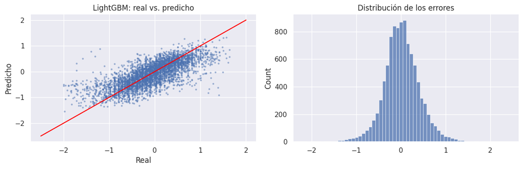

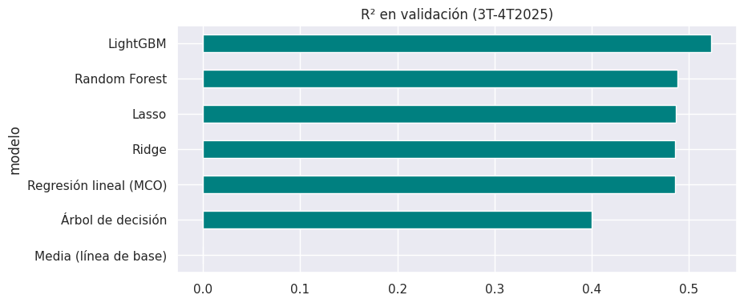

| modelo | RMSE | MAE | R2 |
| --- | --- | --- | --- |
| LightGBM | 0.4243 | 0.3212 | 0.5228 |
| Random Forest | 0.4393 | 0.3352 | 0.4884 |
| Lasso | 0.4400 | 0.3383 | 0.4867 |
| Ridge | 0.4406 | 0.3384 | 0.4855 |
| Regresión lineal (MCO) | 0.4406 | 0.3384 | 0.4855 |
| Árbol de decisión | 0.4758 | 0.3656 | 0.4000 |
| Media (línea de base) | 0.6142 | 0.4796 | -0.0001 |

```python
ruta_mlflow = "/content/mlflow" if EN_COLAB else os.path.abspath("mlflow_local")
os.makedirs(ruta_mlflow, exist_ok=True)
mlflow.set_tracking_uri(f"sqlite:///{ruta_mlflow}/mlflow.db")
if mlflow.get_experiment_by_name("tfm_salarios_mujeres") is None:
    mlflow.create_experiment("tfm_salarios_mujeres", artifact_location=os.path.join(ruta_mlflow, "artefactos"))
mlflow.set_experiment("tfm_salarios_mujeres")

MODELOS = {
    "Regresión lineal (MCO)": (LinearRegression(), "onehot"),
    "Ridge": (make_pipeline(StandardScaler(), RidgeCV(alphas=np.logspace(-3, 3, 13))), "onehot"),
    "Lasso": (make_pipeline(StandardScaler(), LassoCV(n_alphas=30, cv=3, random_state=SEMILLA, n_jobs=-1)), "onehot"),
    "Árbol de decisión": (DecisionTreeRegressor(max_depth=10, min_samples_leaf=50, random_state=SEMILLA), "onehot"),
    "Random Forest": (RandomForestRegressor(n_estimators=100, max_features=0.3, min_samples_leaf=20, n_jobs=-1,
                                            random_state=SEMILLA), "onehot"),
    "LightGBM": (lgb.LGBMRegressor(n_estimators=600, learning_rate=0.03, num_leaves=31, min_child_samples=50,
                                   subsample=0.8, subsample_freq=1, colsample_bytree=0.8, random_state=SEMILLA,
                                   verbose=-1), "categorias"),
}
resultados, entrenados = [], {}
media = np.average(ytr, weights=wtr)
resultados.append({"modelo": "Media (línea de base)", **saca_metricas(yva, np.full(len(yva), media), wva, "Media", False)})
for nombre, (modelo, datos) in MODELOS.items():
    Xtr, Xva = (Xtr_oh, Xva_oh) if datos == "onehot" else (Xtr_cat, Xva_cat)
    with mlflow.start_run(run_name=nombre):
        if hasattr(modelo, "steps"):          # en un pipeline el peso se pasa al último paso
            modelo.fit(Xtr, ytr, **{f"{modelo.steps[-1][0]}__sample_weight": wtr})
        else:
            modelo.fit(Xtr, ytr, sample_weight=wtr)
        met = saca_metricas(yva, modelo.predict(Xva), wva, nombre, graficar=nombre == "LightGBM")
        mlflow.log_params({"modelo": nombre, "variables": Xtr.shape[1]})
        mlflow.log_metrics({k.lower(): v for k, v in met.items()})
    entrenados[nombre] = modelo
    resultados.append({"modelo": nombre, **met})
tabla_modelos = pd.DataFrame(resultados).set_index("modelo").sort_values("R2", ascending=False)
tabla_modelos["R2"].sort_values().plot(kind="barh", figsize=(9, 4), color="teal", title="R² en validación (3T-4T2025)")
plt.show()
tabla_modelos.round(4)
```

**Comentarios**

Todos los modelos superan con claridad a la línea de base. LightGBM es el mejor (R² de 0,52 en validación), seguido por Random Forest y los modelos lineales (0,49). La ventaja de los árboles sobre la regresión lineal es pequeña: la mayor parte de la relación entre las características y el salario es aproximadamente lineal en logaritmos, como supone la ecuación de Mincer. Ridge y Lasso quedan prácticamente igual que MCO: con decenas de miles de observaciones la regularización casi no cambia el ajuste. (En versiones anteriores probamos un *stacking* de Random Forest y LightGBM: no superaba a LightGBM solo y lo descartamos.)

### 5.3 Selección de variables

Dos criterios complementarios: **Lasso** (las variables con todos sus coeficientes en cero no aportan dada la información de las demás) e **importancia por permutación** de LightGBM en validación (cuánto empeora el R² si se desordena al azar cada variable). Retenemos las variables con importancia mayor a 0,001 de R² más el núcleo de la ecuación de Mincer, y comprobamos que el modelo reducido no pierde capacidad predictiva.

```python
lasso = entrenados["Lasso"][-1]
coef_lasso = pd.Series(lasso.coef_, index=Xtr_oh.columns)
origen = {col: next((v for v in VARIABLES if col == v or col.startswith(v + "_")), col) for col in Xtr_oh.columns}
lasso_por_variable = coef_lasso.abs().groupby(origen).max()

perm = permutation_importance(entrenados["LightGBM"], Xva_cat, yva, sample_weight=wva, n_repeats=3,
                              random_state=SEMILLA, scoring="r2", n_jobs=-1)
importancia_perm = pd.Series(perm.importances_mean, index=Xva_cat.columns).sort_values(ascending=False)
SELECCIONADAS = importancia_perm[importancia_perm > 0.001].index.tolist()
SELECCIONADAS += [v for v in ["anios_educ", "exp_pot", "exp_pot2"] if v not in SELECCIONADAS]

# Comparación del modelo con todas las variables y con las seleccionadas
CAT_SEL = [c for c in SELECCIONADAS if c in CATEGORICAS]
Xsel_cat = X_cat[SELECCIONADAS]
Xsel_oh = one_hot(df[SELECCIONADAS], CAT_SEL)
comparacion = {}
for nombre, modelo, Xa in [("LightGBM", lgb.LGBMRegressor(**entrenados["LightGBM"].get_params()), Xsel_cat),
                           ("Regresión lineal (MCO)", LinearRegression(), Xsel_oh)]:
    modelo.fit(Xa[entrenamiento], ytr, sample_weight=wtr)
    comparacion[nombre] = {"R² todas": tabla_modelos.loc[nombre, "R2"],
                           "R² seleccionadas": saca_metricas(yva, modelo.predict(Xa[validacion]), wva, nombre, False)["R2"]}
print(f"Lasso: {(lasso_por_variable == 0).sum()} de {len(lasso_por_variable)} variables con coeficientes en cero")
print(f"Variables seleccionadas: {len(SELECCIONADAS)} de {len(VARIABLES)}")
display(pd.DataFrame(comparacion).T.round(4))
pd.DataFrame({"importancia por permutación (R²)": importancia_perm,
              "Lasso distinto de cero": [lasso_por_variable.get(v, 0) > 0 for v in importancia_perm.index],
              "descripción": [DESCRIPCION.get(v.replace("_faltante", ""), v) for v in importancia_perm.index]}).head(26).round(4)
```

```
LightGBM  RMSE = 0.4303 | MAE = 0.3273 | R² = 0.5093
Regresión lineal (MCO)  RMSE = 0.4422 | MAE = 0.3410 | R² = 0.4818
Lasso: 15 de 96 variables con coeficientes en cero
Variables seleccionadas: 26 de 105
```

|  | R² todas | R² seleccionadas |
| --- | --- | --- |
| LightGBM | 0.5228 | 0.5093 |
| Regresión lineal (MCO) | 0.4855 | 0.4818 |

|  | importancia por permutación (R²) | Lasso distinto de cero | descripción |
| --- | --- | --- | --- |
| jornada_parcial | 0.0979 | True | Jornada parcial (< 35 horas) |
| AGLOMERADO | 0.0586 | True | Aglomerado urbano |
| INTENSI | 0.0366 | True | Intensidad de la ocupación |
| caes_division | 0.0340 | True | Actividad del establecimiento (CAES, 2 dígitos) |
| anios_educ | 0.0294 | True | Años de educación |
| PP07K | 0.0229 | True | Comprobante de pago |
| cno_caracter | 0.0214 | True | Carácter de la ocupación (CNO, 2 dígitos) |
| PP07H | 0.0153 | True | Descuento jubilatorio (empleo registrado) |
| PP07B1_01 | 0.0052 | True | Cobra un plan social por este trabajo |
| exp_pot | 0.0051 | True | Experiencia potencial (años) |
| tamano_establecimiento | 0.0049 | True | Personas que trabajan en el establecimiento |
| PP04A1 | 0.0045 | True | Nivel del Estado (nacional, provincial, munici... |
| calificacion | 0.0036 | True | Calificación de la ocupación |
| parentesco | 0.0034 | True | Parentesco con el jefe/a de hogar |
| IV2 | 0.0021 | True | Ambientes de la vivienda |
| PP3F_TOT | 0.0017 | True | Horas en otras ocupaciones |
| PP07F1 | 0.0016 | True | Le dan de comer en el trabajo |
| IV4 | 0.0016 | True | Cubierta del techo |
| V14 | 0.0016 | True | Pidió préstamos a familiares o amigos |
| hijos_propios_menores_18 | 0.0015 | True | Hijos propios menores de 18 años |
| servicio_domestico_hogar | 0.0014 | True | El hogar tiene servicio doméstico |
| estado_civil | 0.0013 | True | Estado civil |
| V17 | 0.0013 | True | Vendió pertenencias |
| PP04B2 | 0.0012 | False | Cantidad de casas en que trabaja (servicio dom... |
| antiguedad | 0.0010 | True | Antigüedad en el empleo (tramos de 1 a 6) |
| PP03K | 0.0009 | True | Motivo de búsqueda de otro empleo |

**Comentarios**

Los dos criterios coinciden en lo esencial: las variables con más importancia por permutación (jornada, aglomerado, intensidad, educación, actividad, comprobante de pago, ocupación y registro) tienen coeficientes Lasso distintos de cero; Lasso anula sobre todo variables de vivienda y del hogar que repiten información. Con 26 de las 105 variables el modelo pierde apenas una centésima de R²: es más simple de explicar y más fácil de aplicar en una empresa, que no necesita recolectar decenas de datos.

### 5.4 Optimización y validación cruzada

Buscamos los mejores hiperparámetros de LightGBM con GridSearchCV y **validación cruzada de 5 pliegues agrupada por hogar** (GroupKFold): todas las personas de un hogar quedan en el mismo pliegue. Luego comparamos en esos pliegues el R² de la regresión lineal y de LightGBM: la **media** indica el sesgo y la **dispersión**, la varianza.

```
Mejores parámetros: {'learning_rate': 0.05, 'min_child_samples': 100, 'n_estimators': 300, 'num_leaves': 15}
LightGBM optimizado (validación)  RMSE = 0.4271 | MAE = 0.3261 | R² = 0.5165
```

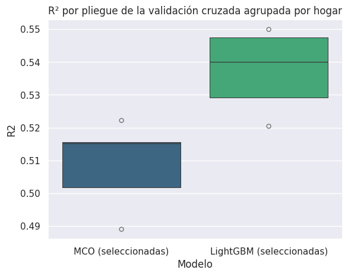

|  | MCO (seleccionadas) | LightGBM (seleccionadas) |
| --- | --- | --- |
| mean | 0.509 | 0.537 |
| std | 0.013 | 0.012 |

```python
grilla = {"num_leaves": [15, 31], "n_estimators": [300, 600], "learning_rate": [0.05], "min_child_samples": [50, 100]}
busqueda = GridSearchCV(lgb.LGBMRegressor(subsample=0.8, subsample_freq=1, colsample_bytree=0.8, random_state=SEMILLA,
                                          verbose=-1),
                        grilla, cv=GroupKFold(n_splits=5), scoring="neg_root_mean_squared_error", n_jobs=-1)
busqueda.fit(Xsel_cat[entrenamiento], ytr, groups=grupos[entrenamiento], sample_weight=wtr)
mejor = busqueda.best_estimator_
print(f"Mejores parámetros: {busqueda.best_params_}")
with mlflow.start_run(run_name="LightGBM optimizado"):
    mlflow.log_params(busqueda.best_params_)
    met_opt = saca_metricas(yva, mejor.predict(Xsel_cat[validacion]), wva, "LightGBM optimizado (validación)", False)
    mlflow.log_metrics({k.lower(): v for k, v in met_opt.items()})

# Comparación por validación cruzada (como cross_val_lin() en el módulo de Minería de datos)
res_cv = {nombre: cross_val_score(modelo, Xa[entrenamiento], ytr, groups=grupos[entrenamiento], cv=GroupKFold(n_splits=5),
                                  scoring="r2", params={"sample_weight": wtr})
          for nombre, (modelo, Xa) in {"MCO (seleccionadas)": (LinearRegression(), Xsel_oh),
                                       "LightGBM (seleccionadas)": (lgb.LGBMRegressor(**mejor.get_params()), Xsel_cat)}.items()}
sns.boxenplot(x="Modelo", y="R2", data=pd.DataFrame(res_cv).melt(var_name="Modelo", value_name="R2"), palette="viridis")
plt.title("R² por pliegue de la validación cruzada agrupada por hogar")
plt.show()
pd.DataFrame(res_cv).agg(["mean", "std"]).round(3)
```

**Comentarios**

La combinación elegida usa árboles pequeños, lo que indica que no hace falta un modelo muy complejo. En la validación cruzada LightGBM tiene la media más alta (menor sesgo) y una dispersión entre pliegues tan baja como la de la regresión lineal: el resultado no depende de qué hogares caen en cada pliegue.

## 6. Evaluación en el futuro inmediato y estabilidad

### 6.1 Evaluación final en el 1T2026

Reentrenamos el modelo optimizado con entrenamiento + validación (1T2024-4T2025) y lo evaluamos en el 1T2026, un trimestre que no participó en ninguna decisión. Como referencia evaluamos también la regresión lineal.

```
LightGBM optimizado - Prueba 1T2026  RMSE = 0.4578 | MAE = 0.3444 | R² = 0.4350
```

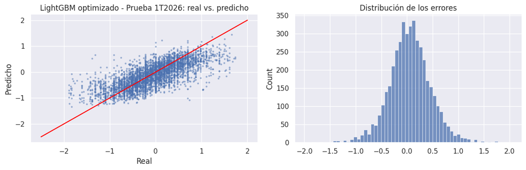

```
LightGBM optimizado - Prueba 1T2026 (mujeres nuevas)  RMSE = 0.4643 | MAE = 0.3518 | R² = 0.4045
Regresión lineal (MCO) - Prueba 1T2026  RMSE = 0.4700 | MAE = 0.3524 | R² = 0.4043
Regresión lineal (MCO) - Prueba 1T2026 (mujeres nuevas)  RMSE = 0.4762 | MAE = 0.3575 | R² = 0.3736
```

|  | modelo | conjunto | RMSE | MAE | R2 |
| --- | --- | --- | --- | --- | --- |
| 0 | LightGBM optimizado | Prueba 1T2026 | 0.4578 | 0.3444 | 0.4350 |
| 1 | LightGBM optimizado | Prueba 1T2026 (mujeres nuevas) | 0.4643 | 0.3518 | 0.4045 |
| 2 | Regresión lineal (MCO) | Prueba 1T2026 | 0.4700 | 0.3524 | 0.4043 |
| 3 | Regresión lineal (MCO) | Prueba 1T2026 (mujeres nuevas) | 0.4762 | 0.3575 | 0.3736 |

```python
hasta_2025 = m & (df["t"] <= 7)
final_lgbm = lgb.LGBMRegressor(**mejor.get_params()).fit(Xsel_cat[hasta_2025], y[hasta_2025], sample_weight=w[hasta_2025])
final_mco = LinearRegression().fit(Xsel_oh[hasta_2025], y[hasta_2025], sample_weight=w[hasta_2025])
evaluacion = []
for nombre, modelo, Xa in [("LightGBM optimizado", final_lgbm, Xsel_cat), ("Regresión lineal (MCO)", final_mco, Xsel_oh)]:
    for conjunto, mascara in [("Prueba 1T2026", prueba), ("Prueba 1T2026 (mujeres nuevas)", prueba_nuevas)]:
        met = saca_metricas(y[mascara], modelo.predict(Xa[mascara]), w[mascara], f"{nombre} - {conjunto}",
                            graficar=(nombre == "LightGBM optimizado" and conjunto == "Prueba 1T2026"))
        evaluacion.append({"modelo": nombre, "conjunto": conjunto, **met})
EVALUACION = pd.DataFrame(evaluacion)
with mlflow.start_run(run_name="Modelo final - prueba 1T2026"):
    mlflow.log_metrics({"rmse_prueba": EVALUACION.RMSE[0], "mae_prueba": EVALUACION.MAE[0], "r2_prueba": EVALUACION.R2[0]})
    mlflow.lightgbm.log_model(final_lgbm, name="modelo_final")
EVALUACION.round(4)
```

### 6.2 ¿Es estable el mercado de trabajo en el corto plazo?

El supuesto principal del trabajo es que la estructura del mercado laboral es estable a un año. Lo ponemos a prueba de tres maneras:

1. **Validación con origen móvil:** entrenamos con todos los trimestres anteriores a *k* y predecimos el trimestre *k*.
2. **Índice de estabilidad poblacional (PSI):** ¿cambió la composición de las asalariadas? (< 0,10 estable; 0,10-0,25 cambio moderado; > 0,25 reentrenar).
3. **Prueba de Wald:** ¿cambiaron los efectos principales entre 2024 y 2025?

```python
origen_movil = []
for k in range(4, 9):
    antes, ahora = m & (df["t"] < k), m & (df["t"] == k)
    modelo_k = lgb.LGBMRegressor(**mejor.get_params()).fit(Xsel_cat[antes], y[antes], sample_weight=w[antes])
    mco_k = LinearRegression().fit(Xsel_oh[antes], y[antes], sample_weight=w[antes])
    for nombre, pred in [("LightGBM", modelo_k.predict(Xsel_cat[ahora])), ("MCO", mco_k.predict(Xsel_oh[ahora]))]:
        origen_movil.append({"trimestre predicho": str(df.loc[ahora, "periodo"].iloc[0]), "modelo": nombre,
                             "R2": r2_score(y[ahora], pred, sample_weight=w[ahora])})
ORIGEN_MOVIL = pd.DataFrame(origen_movil)

PSI = pd.DataFrame({str(p): {v: psi(df.loc[entrenamiento, v], df.loc[m & (df["periodo"] == p), v]) for v in SELECCIONADAS + ["y"]}
                    for p in sorted(df.loc[m & (df["t"] > 5), "periodo"].unique())})
PSI.index = [DESCRIPCION.get(v, v) for v in PSI.index]

CLAVE = [v for v in ["anios_educ", "exp_pot", "PP07H", "jornada_parcial", "antiguedad", "PP07C"] if v in SELECCIONADAS]
datos_wald = df[m & df["ANO4"].isin([2024, 2025])].copy()
datos_wald["anio_2025"] = (datos_wald["ANO4"] == 2025).astype(float)
modelo_wald = smf.wls(ols_formula(SELECCIONADAS, "y", CATEGORICAS) + " + anio_2025 + " + " + ".join(f"{v}:anio_2025" for v in CLAVE),
                      data=datos_wald, weights=datos_wald["PONDIIO"] / datos_wald["PONDIIO"].mean()).fit(
    cov_type="cluster", cov_kwds={"groups": pd.factorize(datos_wald["id_hogar"])[0]})
prueba_wald = modelo_wald.wald_test(", ".join(f"{v}:anio_2025 = 0" for v in CLAVE), scalar=True)

fig = px.line(ORIGEN_MOVIL, x="trimestre predicho", y="R2", color="modelo", markers=True,
              title="R² al predecir cada trimestre con los anteriores (validación con origen móvil)")
fig.show()
print(f"PSI máximo: {PSI.values.max():.3f} | Wald (H0: los efectos no cambiaron entre 2024 y 2025): "
      f"F = {float(prueba_wald.statistic):.2f}, p-valor = {float(prueba_wald.pvalue):.4f}")
pd.DataFrame({"variable": [DESCRIPCION.get(v, v) for v in CLAVE],
              "efecto 2024 (%)": [100 * (np.exp(modelo_wald.params[v]) - 1) for v in CLAVE],
              "efecto 2025 (%)": [100 * (np.exp(modelo_wald.params[v] + modelo_wald.params[f"{v}:anio_2025"]) - 1) for v in CLAVE],
              "p-valor del cambio": [modelo_wald.pvalues[f"{v}:anio_2025"] for v in CLAVE]}).round(3)
```

[interactive chart not shown]

```
PSI máximo: 0.039 | Wald (H0: los efectos no cambiaron entre 2024 y 2025): F = 44.07, p-valor = 0.0000
```

|  | variable | efecto 2024 (%) | efecto 2025 (%) | p-valor del cambio |
| --- | --- | --- | --- | --- |
| 0 | Años de educación | 3.525 | 3.041 | 0.175 |
| 1 | Experiencia potencial (años) | 0.660 | 0.615 | 0.612 |
| 2 | Descuento jubilatorio (empleo registrado) | 33.668 | 19.153 | 0.000 |
| 3 | Jornada parcial (< 35 horas) | 21.074 | 24.137 | 0.146 |
| 4 | Antigüedad en el empleo (tramos de 1 a 6) | 2.913 | 3.222 | 0.756 |

**Respuestas**

- **Capacidad predictiva a un año:** en el 1T2026 el modelo explica alrededor del 44% de la variabilidad del salario relativo (40% la regresión lineal), y el 40% para las mujeres que nunca vio: no depende de "recordar" a las encuestadas del panel. Estos valores son habituales en ecuaciones salariales con encuestas de hogares, que no miden la habilidad, el desempeño ni la empresa concreta.
- **Origen móvil:** el R² de LightGBM se mantiene entre 0,44 y 0,55 al predecir cada trimestre con los anteriores, siempre por encima de la regresión lineal.
- **PSI:** ninguna variable supera 0,10: la **composición** de las asalariadas casi no cambió.
- **Wald:** los efectos sí cambiaron. El cambio principal es la **prima del empleo registrado**, que bajó del 34% al 19% entre 2024 y 2025, en plena desinflación; la educación, la experiencia y la jornada no cambiaron de forma significativa.
- **Conclusión:** el mercado cambió más en sus "precios" que en su composición. El supuesto de estabilidad es razonable a un año, pero el modelo debe **reentrenarse cada trimestre**, con el PSI y la cobertura de las bandas como alertas.

## 7. ¿Qué determina el salario de las mujeres?

### 7.1 Ecuación de Mincer ampliada

Estimamos la regresión lineal con las variables seleccionadas y todos los trimestres, ponderada y con errores estándar agrupados por hogar. Cada coeficiente se expresa como **efecto porcentual** sobre el salario horario, 100 × (e^β − 1), con las demás variables constantes. Antes comprobamos la multicolinealidad con el VIF y estimamos la ecuación clásica (educación, experiencia y registro) como referencia.

```
VIF máximo de las variables numéricas: 1.57
Ecuación clásica: R² = 0.327 | educación 8.6% por año | registro 52%
Ecuación ampliada: n = 45,504 | R² = 0.500 | efectos: 143 | significativos al 5%: 77
```

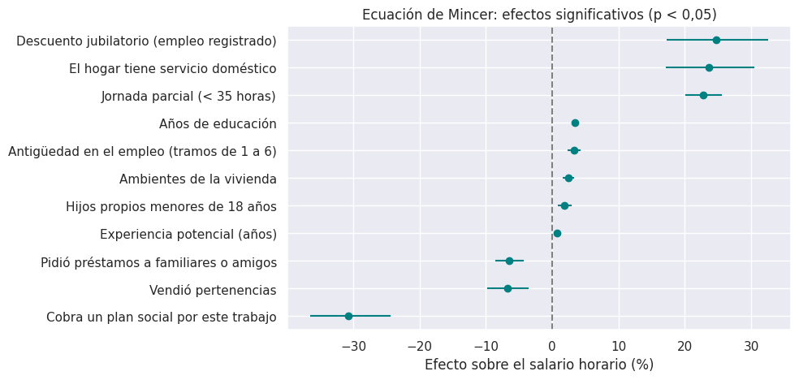

```python
datos_mincer = df[m].copy()
NUM_SEL = [v for v in SELECCIONADAS if v not in CATEGORICAS]
vif = vif_modelo(ols_formula([v for v in NUM_SEL if v != "exp_pot2"], "y"), datos_mincer)
print(f"VIF máximo de las variables numéricas: {vif['VIF'].max():.2f}")

robusto = dict(cov_type="cluster", cov_kwds={"groups": pd.factorize(datos_mincer["id_hogar"])[0]})
pesos_mincer = datos_mincer["PONDIIO"] / datos_mincer["PONDIIO"].mean()
mincer_base = smf.wls("y ~ anios_educ + exp_pot + exp_pot2 + PP07H", data=datos_mincer, weights=pesos_mincer).fit(**robusto)
mincer = smf.wls(ols_formula(SELECCIONADAS, "y", CATEGORICAS), data=datos_mincer, weights=pesos_mincer).fit(**robusto)
print(f"Ecuación clásica: R² = {mincer_base.rsquared:.3f} | educación {100 * (np.exp(mincer_base.params['anios_educ']) - 1):.1f}% "
      f"por año | registro {100 * (np.exp(mincer_base.params['PP07H']) - 1):.0f}%")
print(f"Ecuación ampliada: n = {int(mincer.nobs):,} | R² = {mincer.rsquared:.3f} | efectos: {len(mincer.params) - 1} "
      f"| significativos al 5%: {(mincer.pvalues.drop('Intercept') < 0.05).sum()}")

# Efectos porcentuales con su intervalo de confianza
ic = mincer.conf_int()
coeficientes = pd.DataFrame({"efecto_%": 100 * (np.exp(mincer.params) - 1), "ic_inf_%": 100 * (np.exp(ic[0]) - 1),
                             "ic_sup_%": 100 * (np.exp(ic[1]) - 1), "p_valor": mincer.pvalues}).drop("Intercept")
coeficientes.insert(0, "variable", [nombre_legible(t, DESCRIPCION) for t in coeficientes.index])
significativos = coeficientes[~coeficientes.index.str.startswith("C(") & (coeficientes.index != "exp_pot2")
                              & (coeficientes["p_valor"] < 0.05)].sort_values("efecto_%")
fig, ax = plt.subplots(figsize=(10, 0.35 * len(significativos) + 1))
ax.errorbar(significativos["efecto_%"], significativos["variable"],
            xerr=[significativos["efecto_%"] - significativos["ic_inf_%"], significativos["ic_sup_%"] - significativos["efecto_%"]],
            fmt="o", color="teal")
ax.axvline(0, ls="--", c="grey")
ax.set(xlabel="Efecto sobre el salario horario (%)", title="Ecuación de Mincer: efectos significativos (p < 0,05)")
plt.tight_layout()
plt.show()
```

**Respuestas**

- **VIF:** todos muy por debajo de 5; no hay multicolinealidad que distorsione los coeficientes.
- **Ecuación clásica:** educación, experiencia y registro explican el 33% de la variabilidad del salario relativo. Cada año de educación se asocia con un salario un 8,6% mayor y el empleo registrado con un 52% más.
- **Ecuación ampliada:** con las 26 variables seleccionadas el R² sube a 0,50. Los efectos de la educación y del registro se reducen a menos de la mitad (3,4% por año y 25%): en la ecuación clásica recogían también el efecto de la ocupación, la actividad y el territorio, que van asociados a ellos. Cada tramo de antigüedad suma un 3,3%; cobrar un plan social por el trabajo se asocia con un salario un 31% menor.
- **Un resultado contraintuitivo: la jornada parcial** se paga un 23% más *por hora*. No es una paradoja: la jornada parcial femenina se concentra en docencia y salud, donde el pago por hora es alto.

### 7.2 Peso de cada determinante: valores SHAP

SHAP reparte cada predicción del modelo LightGBM entre las variables. El promedio de los valores absolutos ordena los determinantes por su **peso explicativo**; al agregarlos por bloque distinguimos lo accionable de lo estructural.

```python
X_shap = Xsel_cat[prueba]
contribuciones = final_lgbm.predict(X_shap, pred_contrib=True)[:, :-1]
IMPORTANCIA = pd.DataFrame({"variable": X_shap.columns, "|SHAP| medio": np.abs(contribuciones).mean(axis=0)})
IMPORTANCIA["variable_base"] = IMPORTANCIA["variable"].str.replace("_faltante", "", regex=False)
IMPORTANCIA["descripción"] = IMPORTANCIA["variable_base"].map(DESCRIPCION).fillna(IMPORTANCIA["variable_base"])
IMPORTANCIA["bloque"] = IMPORTANCIA["variable_base"].map(bloque_de)
IMPORTANCIA["carácter"] = IMPORTANCIA["bloque"].map(CARACTER)
IMPORTANCIA["% de la importancia"] = 100 * IMPORTANCIA["|SHAP| medio"] / IMPORTANCIA["|SHAP| medio"].sum()
IMPORTANCIA = IMPORTANCIA.sort_values("|SHAP| medio", ascending=False)

fig = px.bar(IMPORTANCIA.head(15).iloc[::-1], x="% de la importancia", y="descripción", color="bloque", orientation="h",
             title="Los 15 determinantes con mayor peso en el salario de las mujeres (SHAP, 1T2026)", height=550)
fig.update_layout(yaxis_title="")
fig.show()
por_bloque = IMPORTANCIA.groupby(["carácter", "bloque"])["% de la importancia"].sum().round(1).reset_index()
fig = px.sunburst(por_bloque, path=["carácter", "bloque"], values="% de la importancia",
                  title="Peso de cada bloque: factores accionables y estructurales")
fig.show()
```

[interactive chart not shown]

**Respuestas**

- Los determinantes con más peso son el **aglomerado** (12% de la importancia), el **descuento jubilatorio** (10%), la **jornada parcial** (10%), los **años de educación** (10%), el **comprobante de pago** (9%; con el descuento jubilatorio, las dos caras del empleo registrado), la **actividad** del establecimiento (9%) y el **carácter de la ocupación** (7%).
- Alrededor de **dos tercios** (63%) de la importancia corresponde a factores sobre los que pueden actuar las empresas y la política laboral (registro, jornada, ocupación, tamaño), un **14%** a la propia persona (educación, experiencia y antigüedad) y un **23%** a factores estructurales (territorio, vivienda y hogar).
- SHAP y la ecuación de Mincer coinciden en el orden de los factores principales: el *machine learning* no contradice a la economía laboral, la complementa con interacciones.

### 7.3 Hogar y cuidados: ¿por qué los hijos pesan poco en el salario por hora?

Que los hijos tengan poco peso en el modelo **no significa que no importen**. Estudiamos tres canales por los que el hogar puede afectar los ingresos de una mujer: el **acceso al empleo** (con todas las mujeres de 18 a 60 años), las **horas** y el **precio de la hora** (con las asalariadas, a igual educación, experiencia y aglomerado). El salario mensual es el salario por hora por las horas, así que en logaritmos su efecto es la suma de los otros dos.

```python
# Canal 1: el acceso al empleo (todas las mujeres de 18 a 60 años)
pob = POBLACION_FEMENINA.rename(columns={"CH06": "edad", "anios_educ_hogar": "anios_educ"})
pob["hijos menores de 6"] = pob["hijos_propios_menores_6"].clip(upper=2).map({0: "Ninguno", 1: "Uno", 2: "Dos o más"})
pob["hijos_0_5"] = pob["hijos_propios_menores_6"]
pob["hijos_6_17"] = (pob["hijos_propios_menores_18"] - pob["hijos_propios_menores_6"]).clip(lower=0)
pob["ocupada"] = (pob["ESTADO"] == 1).astype(float)
pob["horas"] = pob["PP3E_TOT"].where((pob["ESTADO"] == 1) & pob["PP3E_TOT"].between(1, 98))
PARTICIPACION = pob.groupby("hijos menores de 6").apply(lambda g: pd.Series({
    "% ocupadas": 100 * np.average(g["ocupada"], weights=g["PONDERA"]),
    "horas semanales (ocupadas)": np.average(g["horas"].dropna(), weights=g.loc[g["horas"].notna(), "PONDERA"])})
).reindex(["Ninguno", "Uno", "Dos o más"]).round(1)
datos_part = pob.dropna(subset=["anios_educ"])
modelo_participacion = smf.wls("ocupada ~ hijos_0_5 + hijos_6_17 + anios_educ + edad + I(edad ** 2) + C(periodo)",
                               data=datos_part, weights=datos_part["PONDERA"]).fit(cov_type="HC1")
EFECTO_PARTICIPACION = (100 * modelo_participacion.params[["hijos_0_5", "hijos_6_17"]]).round(1).rename(
    {"hijos_0_5": "Cada hijo de 0 a 5 años", "hijos_6_17": "Cada hijo de 6 a 17 años"}).to_frame(
    "cambio en la probabilidad de estar ocupada (puntos %)")

# Canales 2 y 3: las horas y el precio de la hora (asalariadas, a igual educación, experiencia y aglomerado)
dc = df[m].copy()
dc["log_horas"] = np.log(dc["PP3E_TOT"])
dc["log_mensual"] = dc["y"] + dc["log_horas"]
dc["hijos_0_5"] = dc["hijos_propios_menores_6"]
dc["hijos_6_17"] = (dc["hijos_propios_menores_18"] - dc["hijos_propios_menores_6"]).clip(lower=0)
HOGAR_INTERES = ["hijos_0_5", "hijos_6_17", "realiza_tareas_casa", "hacinamiento", "clima_educativo", "educ_pareja"]
regresores = (" + ".join(HOGAR_INTERES + [f"{v}_faltante" for v in HOGAR_INTERES if f"{v}_faltante" in dc])
              + " + anios_educ + exp_pot + exp_pot2 + C(AGLOMERADO)")
filas = []
for resultado, dependiente in [("Salario por hora", "y"), ("Horas semanales", "log_horas"), ("Salario mensual", "log_mensual")]:
    modelo = smf.wls(f"{dependiente} ~ {regresores}", data=dc, weights=dc["PONDIIO"] / dc["PONDIIO"].mean()).fit(
        cov_type="cluster", cov_kwds={"groups": pd.factorize(dc["id_hogar"])[0]})
    filas += [{"resultado": resultado, "variable": DESCRIPCION.get(v, v), "efecto (%)": 100 * (np.exp(modelo.params[v]) - 1),
               "p-valor": modelo.pvalues[v]} for v in HOGAR_INTERES]
CANALES = pd.DataFrame(filas)

display(PARTICIPACION, EFECTO_PARTICIPACION)
fig = px.bar(CANALES[CANALES["variable"].isin([DESCRIPCION[v] for v in ["hijos_0_5", "hijos_6_17", "realiza_tareas_casa"]])],
             x="variable", y="efecto (%)", color="resultado", barmode="group", text_auto=".1f",
             color_discrete_sequence=["#2a9d8f", "#e9c46a", "#e76f51"],
             title="Los cuidados se pagan en horas, no en el precio de la hora (asalariadas)")
fig.update_layout(xaxis_title="", height=450)
fig.show()
```

| hijos menores de 6 | % ocupadas | horas semanales (ocupadas) |
| --- | --- | --- |
| Ninguno | 64.4 | 32.4 |
| Uno | 60.1 | 31.1 |
| Dos o más | 47.6 | 30.6 |

|  | cambio en la probabilidad de estar ocupada (puntos %) |
| --- | --- |
| Cada hijo de 0 a 5 años | -6.2 |
| Cada hijo de 6 a 17 años | -4.6 |

[interactive chart not shown]

**Corrección del sesgo de selección (Heckman).** Solo observamos el salario de las mujeres que trabajan. Si las que trabajan son distintas de las que no en características no medidas, los coeficientes están sesgados (es el mismo problema que la "inferencia de rechazados" del módulo de Scoring). El modelo de Heckman (1979) lo corrige en dos etapas (función heckman_dos_etapas): un probit de la probabilidad de ser asalariada con **todas** las mujeres de 18 a 60 años y la ecuación de salarios con el **inverso del ratio de Mills**. Como restricción de exclusión usamos los hijos y la situación de la pareja, que afectan la decisión de trabajar pero casi no el salario por hora.

```python
heck = pob.copy()
heck["id_hogar"] = heck["CODUSU"] + "_" + heck["NRO_HOGAR"].astype(str)
heck["id_persona"] = heck["id_hogar"] + "_" + heck["COMPONENTE"].astype(str)
heck = heck.merge(df.loc[m, ["id_persona", "periodo", "y"]], on=["id_persona", "periodo"], how="left").dropna(subset=["anios_educ"])
heck["asalariada"] = heck["y"].notna().astype(float)
heck["exp_pot"] = (heck["edad"] - heck["anios_educ"] - 6).clip(lower=0)
heck["exp_pot2"] = heck["exp_pot"] ** 2
heck["con_pareja"] = heck["pareja_ocupada"].notna().astype(float)
heck["pareja_ocupada"] = heck["pareja_ocupada"].fillna(0)
heck["AGLOMERADO"] = heck["AGLOMERADO"].astype(int).astype(str)
probit, mco_sin_corregir, mco_heckman, heck, rho = heckman_dos_etapas(
    heck, "asalariada ~ anios_educ + exp_pot + exp_pot2 + C(AGLOMERADO) + C(periodo) + hijos_0_5 + hijos_6_17"
          " + con_pareja + pareja_ocupada", "y ~ anios_educ + exp_pot + exp_pot2 + C(AGLOMERADO)", "PONDERA", "id_hogar")

# Retornos sin corregir y corregidos, y salario potencial de cada grupo de mujeres respecto de las asalariadas
HECKMAN = pd.DataFrame({
    "sin corregir (%)": [100 * (np.exp(mco_sin_corregir.params[v]) - 1) for v in ["anios_educ", "exp_pot"]] + [np.nan],
    "corregida (%)": [100 * (np.exp(mco_heckman.params[v]) - 1) for v in ["anios_educ", "exp_pot"]] + [mco_heckman.params["imr"]]},
    index=["Año de educación", "Año de experiencia (inicial)", "Inverso del ratio de Mills (lambda)"])
heck["y_potencial"] = mco_heckman.predict(heck.assign(imr=0))
heck["grupo"] = np.select([heck["asalariada"] == 1, heck["ESTADO"] == 1], ["Asalariadas", "Otras ocupadas"], "No ocupadas")
heck["hijos menores de 6"] = heck["hijos_0_5"].clip(upper=2).map({0: "Ninguno", 1: "Uno", 2: "Dos o más"})
potencial = heck.groupby(["grupo", "hijos menores de 6"]).apply(
    lambda g: np.average(g["y_potencial"], weights=g["PONDERA"])).unstack()[["Ninguno", "Uno", "Dos o más"]]
asalariadas = heck["asalariada"] == 1
SALARIO_POTENCIAL = (100 * (np.exp(potencial - np.average(heck.loc[asalariadas, "y_potencial"],
                                                          weights=heck.loc[asalariadas, "PONDERA"])) - 1)).round(1)
print(f"rho = {rho:.2f} | lambda: p-valor = {mco_heckman.pvalues['imr']:.1e}")
display(HECKMAN.round(2))
SALARIO_POTENCIAL
```

```
rho = 0.95 | lambda: p-valor = 1.2e-36
```

|  | sin corregir (%) | corregida (%) |
| --- | --- | --- |
| Año de educación | 10.17 | 13.25 |
| Año de experiencia (inicial) | 2.47 | 5.66 |
| Inverso del ratio de Mills (lambda) | NaN | 0.82 |

| hijos menores de 6 grupo | Ninguno | Uno | Dos o más |
| --- | --- | --- | --- |
| Asalariadas | 0.5 | -1.0 | -10.8 |
| No ocupadas | -28.8 | -29.8 | -33.4 |
| Otras ocupadas | -1.4 | -5.9 | -12.3 |

**Interpretación**

- **La maternidad pesa en el acceso al empleo.** El 64% de las mujeres sin hijos pequeños está ocupada, frente al 48% de las que tienen dos o más. A igual edad y educación, cada hijo de 0 a 5 años reduce unos 6 puntos la probabilidad de estar ocupada, y la penalización se concentra en las mujeres con menos educación.
- **Y en las horas, no en el precio de la hora.** Entre las asalariadas, cada hijo de 6 a 17 años se asocia con un 6% menos de horas y hacerse cargo de las tareas de la casa con un 12% menos, lo que se traslada casi completo al salario mensual. Las madres asalariadas no cobran menos *por hora*.
- **Hay selección positiva** (lambda = 0,82, muy significativo): las que trabajan tienen características no observadas asociadas a salarios más altos. Corrigiendo, el retorno de la educación sube del 10% al 13% por año, y las mujeres que no trabajan tendrían un salario por hora un **29% menor** que las asalariadas. La correlación implícita entre los errores es alta (rho = 0,95), así que el resultado depende en parte de la forma funcional del probit.
- **Implicancia:** las políticas de cuidado (jardines maternales, licencias, jornada escolar extendida) actúan sobre la participación y las horas, sobre todo de las menos educadas; para que esas mujeres se incorporen con buenos salarios hace falta combinarlas con formación. La vivienda y el hacinamiento, por su parte, son sobre todo **consecuencia** del ingreso y la educación del hogar, no una causa del salario.

## 8. Territorio, recursos naturales y poder de compra

El aglomerado es el determinante con más peso. Esta sección responde tres preguntas que los cuadros publicados de la EPH no responden: ¿cuánto de la diferencia salarial entre ciudades es **propiamente territorial**?, ¿cuánto queda al descontar el **costo de vida**? y ¿qué pasa en las ciudades de los **polos energéticos y mineros**?

### 8.1 La prima salarial de cada aglomerado: bruta, ajustada y real

- **Prima bruta:** cuánto más (o menos) cobran por hora las asalariadas del aglomerado respecto del promedio del país.
- **Prima ajustada:** el coeficiente del aglomerado en la ecuación de Mincer, es decir, la diferencia que queda **a igual educación, experiencia, ocupación, actividad, registro y hogar**.
- **Prima real:** la prima ajustada descontando el costo de vida de la región, medido con la **Canasta Básica Total (CBT)** que el INDEC valoriza cada mes en las seis regiones (es la canasta con la que se mide la pobreza). En la Patagonia la canasta cuesta alrededor de un 17% más que en el Gran Buenos Aires; en el Noroeste, un 20% menos.

```python
# Prima ajustada: coeficientes del aglomerado en la ecuación de Mincer, centrados en el promedio ponderado del país
codigo = datos_mincer["AGLOMERADO"].str.replace("código ", "").astype(int)
coef_aglomerado = pd.Series({int(t.split("código ")[1].rstrip("]")): valor for t, valor in mincer.params.items()
                             if t.startswith("C(AGLOMERADO)")})
beta = codigo.map(coef_aglomerado).fillna(0)             # el aglomerado de referencia tiene coeficiente 0
peso = datos_mincer["PONDIIO"]
territorio = pd.DataFrame({
    "prima bruta": datos_mincer["y"].groupby(codigo).apply(lambda s: np.average(s, weights=peso[s.index]))
                   - np.average(datos_mincer["y"], weights=peso),
    "prima ajustada": beta.groupby(codigo).first() - np.average(beta, weights=peso)})

# Nivel de precios de cada región: CBT regional respecto del promedio del país (ponderado por las asalariadas)
canasta = pd.read_csv(os.path.join(ruta_datos, "canasta_basica_regional.csv"))
CBT = cbt_por_trimestre(canasta)
region_aglomerado = base.groupby("AGLOMERADO")["REGION"].agg(lambda s: s.mode().iloc[0]).map(REGIONES)
df["region"] = df["AGLOMERADO"].str.replace("código ", "").astype(int).map(region_aglomerado)
df["cbt"] = df.merge(CBT, on=["periodo", "region"], how="left")["cbt"].values
promedio_pais = df[m].groupby("periodo").apply(lambda g: np.average(g["cbt"], weights=g["PONDIIO"]))
df["nivel_precios"] = df["cbt"] / df["periodo"].map(promedio_pais)
nivel_region = df[m].groupby("region")["nivel_precios"].mean()
territorio["región"] = territorio.index.map(region_aglomerado)
territorio["nivel de precios"] = territorio["región"].map(nivel_region)
territorio["prima real"] = territorio["prima ajustada"] - np.log(territorio["nivel de precios"])
for col in ["prima bruta", "prima ajustada", "prima real"]:
    territorio[col] = 100 * (np.exp(territorio[col]) - 1)              # en % respecto del promedio del país

# Características del empleo femenino de cada aglomerado y ubicación para el mapa
division = base["PP04B_COD"].map(division_caes)
df["sector_recursos"] = division.isin(DIVISIONES_RECURSOS).astype(float)
territorio["% empleo registrado"] = 100 * datos_mincer.groupby(codigo).apply(lambda g: np.average(g["PP07H"], weights=g["PONDIIO"]))
territorio["% en minería e hidrocarburos"] = 100 * df[m].groupby(codigo).apply(
    lambda g: np.average(g["sector_recursos"], weights=g["PONDIIO"]))
territorio["asalariadas encuestadas"] = codigo.value_counts()
territorio["aglomerado"] = [AGLOMERADOS[c][0] for c in territorio.index]
territorio["lat"], territorio["lon"] = [AGLOMERADOS[c][1] for c in territorio.index], [AGLOMERADOS[c][2] for c in territorio.index]
territorio["polo"] = territorio.index.map(POLOS).fillna("Resto del país")
TERRITORIO = territorio.round(1).sort_values("prima ajustada", ascending=False)

fig = px.scatter_geo(TERRITORIO.reset_index(), lat="lat", lon="lon", color="prima real", size="asalariadas encuestadas",
                     hover_name="aglomerado", hover_data={"prima bruta": True, "prima ajustada": True, "prima real": True,
                                                          "lat": False, "lon": False},
                     color_continuous_scale="RdBu", color_continuous_midpoint=0, size_max=26, projection="mercator",
                     title="Prima salarial real por aglomerado: a igual perfil y descontando el costo de vida (%)", height=720)
fig.update_geos(fitbounds="locations", showcountries=True, showsubunits=True)
fig.show()
```

[interactive chart not shown]

```python
# Prima ajustada (nominal) y real: cuánto de la diferencia territorial es costo de vida
orden = TERRITORIO.sort_values("prima real")
fig = go.Figure()
for _, fila in orden.iterrows():
    fig.add_trace(go.Scatter(x=[fila["prima ajustada"], fila["prima real"]], y=[fila["aglomerado"]] * 2, mode="lines",
                             line=dict(color="lightgrey"), showlegend=False))
fig.add_trace(go.Scatter(x=orden["prima ajustada"], y=orden["aglomerado"], mode="markers", name="A igual perfil (nominal)",
                         marker=dict(color="#e9c46a", size=9)))
fig.add_trace(go.Scatter(x=orden["prima real"], y=orden["aglomerado"], mode="markers", name="A igual perfil y costo de vida",
                         marker=dict(color="#264653", size=9)))
fig.add_vline(x=0, line_dash="dash", line_color="grey")
fig.update_layout(title="Prima salarial por aglomerado: nominal y real (%)", height=780, xaxis_title="%")
fig.show()
TERRITORIO.groupby("región").apply(lambda g: pd.Series({
    c: np.average(g[c], weights=g["asalariadas encuestadas"]) for c in ["prima bruta", "prima ajustada", "prima real"]}
    | {"nivel de precios": g["nivel de precios"].iloc[0]})).round(2).sort_values("prima real")
```

[interactive chart not shown]

| región | prima bruta | prima ajustada | prima real | nivel de precios |
| --- | --- | --- | --- | --- |
| Cuyo | -11.17 | -9.69 | -7.09 | 1.0 |
| Noreste | -24.15 | -17.40 | -3.46 | 0.9 |
| Pampeana | 1.48 | 1.55 | 0.37 | 1.0 |
| Gran Buenos Aires | 7.65 | 3.97 | 1.29 | 1.0 |
| Noroeste | -20.62 | -16.45 | 1.39 | 0.8 |
| Patagonia | 29.79 | 21.54 | 1.72 | 1.2 |

**Respuestas**

- **A igual perfil, el territorio pesa mucho en pesos:** las asalariadas de la **Patagonia** cobran por hora un 22% más que el promedio del país y las del **Noreste** y el **Noroeste**, un 17% menos: casi 40 puntos entre regiones. La **Ciudad de Buenos Aires** es el caso de composición: su prima bruta (+45%) baja al 13% a igual perfil, porque sus asalariadas son más educadas y tienen empleos más calificados.
- **Pero casi toda esa diferencia es costo de vida.** Al descontar la canasta regional, la distancia entre regiones cae de casi 40 a menos de 10 puntos: la Patagonia queda apenas un 2% por encima del promedio y el Noroeste también (+1%). Las diferencias reales que quedan son **entre ciudades**: la Ciudad de Buenos Aires (+10%), Neuquén-Plottier (+9%) y Santa Rosa (+9%) pagan más de lo que cuesta vivir en ellas; San Juan (−15%), Concordia (−10%) y Mendoza (−9%), menos.
- **Para una empresa** con sucursales en varias provincias, la prima real es la referencia adecuada para fijar adicionales por zona; **para la política pública**, indica dónde la desventaja salarial es real y no solo de precios.

### 8.2 Polos energéticos y mineros: ¿llega la riqueza de los recursos naturales al salario de las mujeres?

Argentina vive una expansión de los hidrocarburos no convencionales (Vaca Muerta) y de la minería (litio, cobre, oro). Son sectores con muy poco empleo femenino directo, pero pueden elevar los salarios de toda la ciudad por la demanda de servicios. Comparamos la prima de los aglomerados de los polos de **hidrocarburos** (Neuquén-Plottier y Comodoro Rivadavia) y **mineros** (Catamarca, Salta, Jujuy, San Juan y Río Gallegos) con el resto del país.

```python
POLOS_RESUMEN = TERRITORIO.groupby("polo").apply(lambda g: pd.Series({
    "aglomerados": ", ".join(g["aglomerado"]),
    "% de asalariadas en minería e hidrocarburos": np.average(g["% en minería e hidrocarburos"], weights=g["asalariadas encuestadas"]),
    "prima ajustada (%)": np.average(g["prima ajustada"], weights=g["asalariadas encuestadas"]),
    "prima real (%)": np.average(g["prima real"], weights=g["asalariadas encuestadas"])})).round(1)

# Escenario: ¿cuánto ganaría una asalariada de un polo minero si su ciudad alcanzara la prima REAL de los polos petroleros?
brecha_polos = ((1 + POLOS_RESUMEN.loc["Hidrocarburos", "prima real (%)"] / 100)
                / (1 + POLOS_RESUMEN.loc["Minería", "prima real (%)"] / 100) - 1)
en_minero = m & (df["t"] == 8) & df["AGLOMERADO"].str.replace("código ", "").astype(int).map(POLOS).eq("Minería")
salario_minero = mediana_ponderada(df.loc[en_minero, "salario_horario"], df.loc[en_minero, "PONDIIO"]) * HORAS_MES_COMPLETO
print(f"Escenario: +{100 * brecha_polos:.0f}% de salario, unos $ {salario_minero * brecha_polos:,.0f} más por mes a jornada "
      f"completa para la asalariada mediana de los polos mineros (1T2026)")
POLOS_RESUMEN
```

```
Escenario: +5% de salario, unos $ 43,157 más por mes a jornada completa para la asalariada mediana de los polos mineros (1T2026)
```

| polo | aglomerados | % de asalariadas en minería e hidrocarburos | prima ajustada (%) | prima real (%) |
| --- | --- | --- | --- | --- |
| Hidrocarburos | Neuquén-Plottier, Comodoro Rivadavia-Rada Tilly | 4.5 | 26.0 | 5.5 |
| Minería | Río Gallegos, Gran Salta, Gran Catamarca, Gran... | 0.6 | -11.7 | 0.1 |
| Resto del país | Ushuaia-Río Grande, Viedma-Carmen de Patagones... | 0.1 | -2.2 | -0.5 |

**Respuestas**

- **El empleo directo es pequeño:** en los polos petroleros, 1 de cada 20 asalariadas trabaja en el sector (5% en Neuquén-Plottier); en los mineros, menos de 1 de cada 100. Si los recursos naturales mejoran el salario de las mujeres, lo hacen sobre todo de forma **indirecta**, a través del mercado de trabajo local (comercio, salud, educación, servicios a las empresas).
- **Los polos petroleros ya muestran ese efecto:** a igual perfil pagan un 26% más que el promedio del país y, aun descontando la canasta patagónica, un 5,5% más. Neuquén-Plottier (Vaca Muerta) es la ciudad con mayor prima a igual perfil y la segunda en términos reales.
- **Los polos mineros todavía no:** en pesos pagan un 12% menos que el promedio; descontando su canasta más barata quedan justo en el promedio (+0,1%), con San Juan claramente por debajo (−15%). El escenario calculado arriba muestra lo que está en juego si esas ciudades alcanzaran la prima real de los polos petroleros. **No es un pronóstico**: es la magnitud del efecto que la expansión minera debería generar para replicar la experiencia de Vaca Muerta. Monitorear la prima de estos aglomerados trimestre a trimestre permite detectar si ese efecto aparece.

### 8.3 ¿Alcanza el salario? El *welfare ratio* de Robert Allen

Allen (2001) midió el nivel de vida de los trabajadores como el cociente entre lo que gana un trabajador a tiempo completo y lo que cuesta sostener a una familia con una **canasta de consumo básica valorizada a precios locales**. Aplicamos su método con la canasta oficial argentina:

**welfare ratio = salario horario × 172 horas (jornada completa) / (CBT regional × 3,09 adultos equivalentes)**

El hogar de referencia es el "hogar tipo 2" del INDEC (una pareja con dos hijos, 3,09 adultos equivalentes), casi igual a la familia de 3 adultos equivalentes de Allen. Un valor de 1 significa que un empleo a tiempo completo con ese salario alcanza justo para que la familia no sea pobre.

**¿Es lo mismo que expresar el salario en paridad de poder adquisitivo (PPA)?** No. La PPA convierte monedas con un índice de precios de *todo* el consumo del país; el *welfare ratio* compara el salario con una canasta de **necesidades básicas** valorizada en cada región y cada mes. Por eso capta diferencias de costo de vida entre regiones y responde una pregunta concreta de bienestar. Cuando la línea de comparación es la línea de pobreza internacional del Banco Mundial (como en la sección 11), el *welfare ratio* es solo el salario en PPA reescalado: sirve para comparar países, no agrega información sobre el costo de vida local.

```python
df["welfare_ratio"] = df["salario_horario"] * HORAS_MES_COMPLETO / (df["cbt"] * ADULTOS_EQUIVALENTES)
mediana_wr = lambda g: mediana_ponderada(g["welfare_ratio"], g["PONDIIO"])
debajo_de_1 = lambda g: 100 * np.average(g["welfare_ratio"] < 1, weights=g["PONDIIO"])

# Evolución del welfare ratio mediano: recupera el nivel real que la variable objetivo relativa neutraliza
WR_TRIMESTRE = pd.DataFrame({"Mujeres": df[m].groupby("periodo").apply(mediana_wr),
                             "Varones": df[~m].groupby("periodo").apply(mediana_wr)})
WR_TRIMESTRE.index = WR_TRIMESTRE.index.astype(str)
fig = px.line(WR_TRIMESTRE, markers=True, labels={"value": "Welfare ratio mediano", "periodo": ""},
              title="¿Cuántas familias tipo sostiene fuera de la pobreza un salario mediano a jornada completa?")
fig.add_hline(y=1, line_dash="dash")
fig.show()

# Welfare ratio de las mujeres en el último año, por nivel educativo y región
ultimo_anio = m & (df["t"] >= 5)
WR_EDUCACION = df[ultimo_anio].groupby("nivel_educativo").apply(lambda g: pd.Series({
    "welfare ratio mediano": mediana_wr(g), "% que no alcanza la línea (WR < 1)": debajo_de_1(g)})).reindex(orden_ed).round(2)
WR_REGION = df[ultimo_anio].groupby("region").apply(lambda g: pd.Series({
    "welfare ratio mediano": mediana_wr(g), "% que no alcanza la línea (WR < 1)": debajo_de_1(g)})).round(2)
display(WR_EDUCACION.drop(index="Sin instrucción", errors="ignore"))
WR_REGION.sort_values("welfare ratio mediano")
```

[interactive chart not shown]

| nivel_educativo | welfare ratio mediano | % que no alcanza la línea (WR < 1) |
| --- | --- | --- |
| Primario incompleto | 0.65 | 85.01 |
| Primario completo | 0.55 | 89.86 |
| Secundario incompleto | 0.58 | 88.89 |
| Secundario completo | 0.65 | 81.42 |
| Superior incompleto | 0.81 | 65.63 |
| Superior completo | 1.15 | 39.00 |

| region | welfare ratio mediano | % que no alcanza la línea (WR < 1) |
| --- | --- | --- |
| Cuyo | 0.66 | 73.32 |
| Noreste | 0.71 | 72.54 |
| Noroeste | 0.75 | 67.60 |
| Pampeana | 0.76 | 68.92 |
| Gran Buenos Aires | 0.80 | 64.36 |
| Patagonia | 0.87 | 59.58 |

**Respuestas**

- **El poder de compra se recuperó, pero no alcanza.** El *welfare ratio* mediano de las asalariadas pasó de 0,51 en el 1T2024 (tras la devaluación de diciembre de 2023) a 0,81 a fines de 2025, y bajó a 0,75 en el 1T2026. Es decir: el salario mediano de una asalariada a jornada completa cubre **tres cuartos** de la canasta básica de una familia tipo. Solo en los hogares con más de un ingreso esa familia supera la línea de pobreza.
- **La educación separa a las que sostienen una familia de las que no:** en el último año, entre 8 y 9 de cada 10 asalariadas sin estudios superiores no alcanzarían a sostener a una familia tipo fuera de la pobreza con su salario; con título superior la mediana supera la canasta (1,15), aunque el 39% sigue sin alcanzarla.
- **Por región**, el orden sigue a la prima real y no a la nominal: la Patagonia tiene el mayor *welfare ratio* (0,87) pero el Noroeste (0,75) supera a Cuyo (0,66).
- **Uso en la aplicación:** el simulador informa, para cada perfil, el *welfare ratio* del salario esperado. Es un indicador de "salario adecuado" que una empresa puede usar como piso de referencia y que ningún cuadro publicado ofrece para un perfil concreto.

## 9. Brecha de género y transparencia retributiva

La **Directiva (UE) 2023/970** de transparencia retributiva, que los países de la Unión debían incorporar a su legislación antes de junio de 2026, obliga a las empresas a informar su brecha salarial de género y, si una diferencia de **5% o más** en una categoría de trabajadores no se justifica con criterios objetivos, a realizar una evaluación conjunta con los representantes de los trabajadores. Argentina no tiene una norma equivalente, pero la misma lógica (comparar a igual trabajo o perfil) puede aplicarse con los datos de la EPH.

Un LightGBM entrenado **solo con varones** aprende cómo remunera el mercado a los varones. Aplicado a las mujeres, indica cuánto cobrarían si su perfil se pagara "como el de un varón": la diferencia con su salario real es la brecha **no explicada** por las características observadas.

```python
v = ~m
modelo_varones = lgb.LGBMRegressor(**mejor.get_params()).fit(Xsel_cat[v], y[v], sample_weight=w[v])
df["contrafactual"] = modelo_varones.predict(Xsel_cat)


def brechas(g_m, g_v):
    """Brecha media, explicada y no explicada (en % del salario por hora) de un grupo de mujeres y varones."""
    media = np.average(g_v["y"], weights=g_v["PONDIIO"]) - np.average(g_m["y"], weights=g_m["PONDIIO"])
    no_explicada = np.average(g_m["contrafactual"] - g_m["y"], weights=g_m["PONDIIO"])
    return pd.Series({"brecha observada (%)": 100 * (np.exp(media) - 1),
                      "explicada por características (%)": 100 * (np.exp(media - no_explicada) - 1),
                      "no explicada (%)": 100 * (np.exp(no_explicada) - 1), "mujeres encuestadas": len(g_m)})


BRECHA = brechas(df[m], df[v])
filas = []
for col, titulo in [("calificacion", "Calificación"), ("sector", "Sector"), ("tamano_establecimiento", "Tamaño"), ("rama", "Rama")]:
    for valor, g in df[m].groupby(col):
        if len(g) >= 1000 and valor not in ("Sin dato", "Otros"):
            filas.append({"grupo": f"{titulo}: {valor}", **brechas(g, df[v & (df[col] == valor)])})
BRECHA_GRUPOS = pd.DataFrame(filas).sort_values("no explicada (%)")
fig = px.bar(BRECHA_GRUPOS, x="no explicada (%)", y="grupo", orientation="h", height=620,
             color=BRECHA_GRUPOS["no explicada (%)"] >= 5, color_discrete_map={True: "#e76f51", False: "#2a9d8f"},
             title="Brecha salarial de género no explicada por grupo de trabajadores (umbral de la Directiva: 5%)")
fig.add_vline(x=5, line_dash="dash")
fig.update_layout(showlegend=False, yaxis_title="")
fig.show()
display(BRECHA.round(1).to_frame("total"))
BRECHA_GRUPOS.round(1)
```

[interactive chart not shown]

|  | total |
| --- | --- |
| brecha observada (%) | 4.8 |
| explicada por características (%) | -1.5 |
| no explicada (%) | 6.4 |
| mujeres encuestadas | 45504.0 |

|  | grupo | brecha observada (%) | explicada por características (%) | no explicada (%) | mujeres encuestadas |
| --- | --- | --- | --- | --- | --- |
| 17 | Rama: Servicio doméstico | -8.2 | 0.3 | -8.4 | 9278.0 |
| 0 | Calificación: No calificada | 2.6 | 4.4 | -1.7 | 14627.0 |
| 11 | Rama: Enseñanza | 0.7 | -3.2 | 4.0 | 7173.0 |
| 5 | Sector: Privado | 10.3 | 4.4 | 5.6 | 29190.0 |
| 3 | Calificación: Técnica | 3.5 | -3.9 | 7.7 | 9042.0 |
| 4 | Sector: Estatal | -0.7 | -8.0 | 8.0 | 15544.0 |
| 2 | Calificación: Profesional | 7.1 | -1.0 | 8.2 | 3782.0 |
| 8 | Tamaño: Más de 40 | -3.4 | -10.7 | 8.2 | 13178.0 |
| 9 | Rama: Administración pública | -2.6 | -10.0 | 8.3 | 6277.0 |
| 13 | Rama: Hoteles y restaurantes | 9.2 | 0.8 | 8.4 | 2448.0 |
| 16 | Rama: Salud y servicios sociales | 13.5 | 3.3 | 9.9 | 5266.0 |
| 6 | Tamaño: 6 a 40 | -5.1 | -13.8 | 10.1 | 14179.0 |
| 1 | Calificación: Operativa | 2.8 | -8.1 | 11.8 | 17996.0 |
| 7 | Tamaño: Hasta 5 | -0.5 | -11.4 | 12.3 | 6920.0 |
| 12 | Rama: Finanzas e inmobiliarias | 13.5 | 0.4 | 13.0 | 1068.0 |
| 10 | Rama: Comercio | 12.4 | -1.2 | 13.8 | 5715.0 |
| 14 | Rama: Industria | 13.3 | -0.7 | 14.0 | 1850.0 |
| 18 | Rama: Servicios profesionales y empresariales | -0.3 | -12.8 | 14.4 | 2617.0 |
| 15 | Rama: Otros servicios | 18.3 | 3.0 | 14.8 | 1597.0 |

## 10. Del modelo al producto: bandas salariales y aplicación

### 10.1 Bandas salariales

Una empresa no necesita solo un número: necesita un **rango**. Con *regresión cuantílica conformal* (Romano, Patterson y Candès, 2019) estimamos para cada perfil una banda que contiene el salario real con una probabilidad del 90%: dos LightGBM estiman los percentiles 5 y 95 (entrenamiento), la banda se ajusta con los errores del conjunto de validación y se comprueba su cobertura real en el 1T2026.

```python
NIVEL = 0.90
parametros = {k: v for k, v in mejor.get_params().items() if k not in ("objective", "alpha")}
w_norm = wtr / wtr.mean()        # con la pérdida cuantílica, los ponderadores de la EPH sin normalizar dan valores extremos
cuantil_inf = lgb.LGBMRegressor(**parametros, objective="quantile", alpha=(1 - NIVEL) / 2).fit(Xsel_cat[entrenamiento], ytr, sample_weight=w_norm)
cuantil_sup = lgb.LGBMRegressor(**parametros, objective="quantile", alpha=1 - (1 - NIVEL) / 2).fit(Xsel_cat[entrenamiento], ytr, sample_weight=w_norm)

# Ajuste conformal con el conjunto de validación
puntaje = np.maximum(cuantil_inf.predict(Xsel_cat[validacion]) - yva, yva - cuantil_sup.predict(Xsel_cat[validacion]))
q_ajuste = float(np.quantile(puntaje, min(1.0, np.ceil((len(puntaje) + 1) * NIVEL) / len(puntaje)), method="higher"))

# Cobertura real en el 1T2026, total y por grupos
banda_inf = cuantil_inf.predict(Xsel_cat[prueba]) - q_ajuste
banda_sup = cuantil_sup.predict(Xsel_cat[prueba]) + q_ajuste
resultado_bandas = df.loc[prueba, ["PONDIIO", "calificacion", "PP07H"]].assign(
    cubre=((y[prueba] >= banda_inf) & (y[prueba] <= banda_sup)).values, ancho=np.exp(banda_sup - banda_inf))
cobertura = [{"grupo": "Total", "n": len(resultado_bandas), "cobertura": np.average(resultado_bandas.cubre, weights=resultado_bandas.PONDIIO),
              "ancho mediano (máximo / mínimo)": resultado_bandas.ancho.median()}]
for col in ["calificacion", "PP07H"]:
    for valor, g in resultado_bandas.groupby(col):
        if len(g) >= 100:
            cobertura.append({"grupo": f"{DESCRIPCION.get(col, col)} = {valor}", "n": len(g),
                              "cobertura": np.average(g.cubre, weights=g.PONDIIO), "ancho mediano (máximo / mínimo)": g.ancho.median()})
COBERTURA = pd.DataFrame(cobertura).round(3)
print(f"Ajuste conformal de la banda: {q_ajuste:+.3f} puntos de log-salario")
COBERTURA
```

```
Ajuste conformal de la banda: -0.021 puntos de log-salario
```

|  | grupo | n | cobertura | ancho mediano (máximo / mínimo) |
| --- | --- | --- | --- | --- |
| 0 | Total | 4421 | 0.852 | 3.726 |
| 1 | Calificación de la ocupación = No calificada | 1410 | 0.891 | 4.567 |
| 2 | Calificación de la ocupación = Operativa | 1887 | 0.840 | 3.407 |
| 3 | Calificación de la ocupación = Profesional | 351 | 0.805 | 3.798 |
| 4 | Calificación de la ocupación = Técnica | 771 | 0.841 | 3.332 |
| 5 | Descuento jubilatorio (empleo registrado) = 0.0 | 1847 | 0.866 | 5.076 |
| 6 | Descuento jubilatorio (empleo registrado) = 1.0 | 2574 | 0.843 | 3.135 |

**Comentarios**

Las bandas cubren alrededor del 85% de los salarios del 1T2026, algo menos que el 90% buscado: el mercado del 1T2026 es algo distinto del de 2025 con el que se calibraron. Esa diferencia es en sí misma una **señal de monitoreo**: si la cobertura cae, hay que recalibrar. Las bandas son más angostas para el empleo registrado, donde los salarios están más regulados por convenios.

### 10.2 Exportación del modelo

Guardamos en la carpeta modelos/ del repositorio todo lo que necesita la aplicación: el modelo final, los modelos de las bandas, las variables con sus descripciones, la mediana salarial y la canasta del último trimestre (para expresar las predicciones en pesos y en *welfare ratio*) y las tablas de resultados. La aplicación **no reentrena nada**: solo aplica el modelo, como ocurriría en una empresa.

**Nómina de demostración.** Ninguna empresa publica los salarios individuales de su personal (son datos personales protegidos por la Ley 25.326) y el producto no lo necesita: cada empresa aplica el modelo a su propia nómina. Para mostrar la auditoría funcionando armamos una nómina **simulada** con asalariadas y asalariados de la EPH del 1T2026 del sector de salud y servicios sociales, que no corresponde a ninguna empresa real.

```python
def tipo_de(variable):
    return "categórica" if variable in CATEGORICAS else ("binaria" if variable in binarias or variable.endswith("_faltante") else "numérica")


referencia = df[prueba]
paquete = {
    "modelo": final_lgbm, "cuantil_inf": cuantil_inf, "cuantil_sup": cuantil_sup, "ajuste_banda": q_ajuste, "nivel": NIVEL,
    "variables": SELECCIONADAS, "tipos": {v: tipo_de(v) for v in SELECCIONADAS},
    "categorias": {v: list(Xsel_cat[v].cat.categories) for v in CAT_SEL},
    "descripciones": {v: DESCRIPCION.get(v.replace("_faltante", ""), v) for v in SELECCIONADAS},
    "bloques": {v: bloque_de(v.replace("_faltante", "")) for v in SELECCIONADAS},
    "rangos": {v: (float(df.loc[m, v].quantile(0.01)), float(df.loc[m, v].quantile(0.99))) for v in SELECCIONADAS
               if tipo_de(v) == "numérica"},
    "valores_tipicos": {v: (referencia[v].mode().iloc[0] if v in CATEGORICAS else float(referencia[v].median())) for v in SELECCIONADAS},
    "mediana_salario_hora": float(referencia["mediana_trimestre"].iloc[0]), "periodo_referencia": "1T2026", "moneda": "ARS",
    "aglomerado_region": {f"código {c}": r for c, r in region_aglomerado.items()},
    "nombres_aglomerado": {f"código {c}": AGLOMERADOS[c][0] for c in region_aglomerado.index if c in AGLOMERADOS},
    "cbt_region": CBT[CBT.periodo == 20261].set_index("region")["cbt"].to_dict(),
    "adultos_equivalentes": ADULTOS_EQUIVALENTES, "horas_mes": HORAS_MES_COMPLETO,
}
ruta_modelos = os.path.join(ruta_repo, "modelos")
joblib.dump(paquete, os.path.join(ruta_modelos, "modelo_AR.joblib"))

# Tablas de resultados que muestra la aplicación
TERRITORIO.reset_index().rename(columns={"index": "AGLOMERADO"}).to_csv(os.path.join(ruta_modelos, "prima_aglomerado.csv"), index=False)
POLOS_RESUMEN.to_csv(os.path.join(ruta_modelos, "polos_recursos.csv"))
WR_TRIMESTRE.to_csv(os.path.join(ruta_modelos, "welfare_ratio_trimestre.csv"))
WR_EDUCACION.to_csv(os.path.join(ruta_modelos, "welfare_ratio_educacion.csv"))
WR_REGION.to_csv(os.path.join(ruta_modelos, "welfare_ratio_region.csv"))
IMPORTANCIA.to_csv(os.path.join(ruta_modelos, "importancia_shap.csv"), index=False)
PARTICIPACION.to_csv(os.path.join(ruta_modelos, "participacion_hijos.csv"))
CANALES.to_csv(os.path.join(ruta_modelos, "canales_hogar.csv"), index=False)
SALARIO_POTENCIAL.to_csv(os.path.join(ruta_modelos, "salario_potencial.csv"))
BRECHA_GRUPOS.to_csv(os.path.join(ruta_modelos, "brecha_grupos.csv"), index=False)

# Nómina de demostración (simulada): asalariadas y asalariados de salud del 1T2026
salud = df[(df["t"] == 8) & (df["rama"] == "Salud y servicios sociales")]
nomina = salud.sample(min(300, len(salud)), random_state=SEMILLA)
pd.concat([pd.Series([f"DEMO-{i:03d}" for i in range(1, len(nomina) + 1)], index=nomina.index, name="id_persona"),
           nomina["CH04"].map({1: "Varón", 2: "Mujer"}).rename("sexo"), nomina["salario_horario"].round(2),
           nomina[SELECCIONADAS]], axis=1).to_csv(os.path.join(ruta_modelos, "nomina_demo_AR.csv"), index=False)

# La aplicación debe usar las mismas versiones de scikit-learn y LightGBM con que se guardó el modelo
import plotly, sklearn
with open(os.path.join(ruta_repo, "requirements.txt"), "w") as archivo:
    archivo.write(f"pandas>={pd.__version__}\nnumpy>={np.__version__}\nscikit-learn=={sklearn.__version__}\n"
                  f"lightgbm=={lgb.__version__}\njoblib>={joblib.__version__}\nplotly>={plotly.__version__}\nstreamlit>=1.46\n")

# Experimentos de MLflow en Drive y subida de los resultados a GitHub
shutil.copy(os.path.join(ruta_mlflow, "mlflow.db"), os.path.join(ruta_salida, "mlflow.db"))
guardar_en_github("Modelo final y resultados del TFM (parte I)")
sorted(os.listdir(ruta_modelos))
```

```
On branch main
Your branch is up to date with 'origin/main'.

nothing to commit, working tree clean
Everything up-to-date
```

```
['brecha_grupos.csv',
 'canales_hogar.csv',
 'coeficientes_mincer.csv',
 'comparacion_bloques.csv',
 'comparacion_efectos.csv',
 'comparacion_paises.csv',
 'diccionario_variables.csv',
 'importancia_shap.csv',
 'modelo_AR.joblib',
 'monitoreo_psi.csv',
 'nomina_demo_AR.csv',
 'origen_movil.csv',
 'participacion_hijos.csv',
 'polos_recursos.csv',
 'prima_aglomerado.csv',
 'salario_potencial.csv',
 'welfare_ratio_educacion.csv',
 'welfare_ratio_region.csv',
 'welfare_ratio_trimestre.csv']
```

### 10.3 La aplicación

La aplicación (app/app.py, publicada en Streamlit Community Cloud) está pensada para una persona de recursos humanos o un funcionario, no para un especialista en datos:

| Pestaña | Pregunta que responde |
| --- | --- |
| ¿Cuánto debería cobrar? | Salario de mercado y banda del 90% para un perfil, y si ese salario alcanza para sostener a una familia (*welfare ratio*) |
| Auditoría de nómina | Quiénes cobran por debajo del mercado, cuánto costaría corregirlo y cuál es la brecha de género de la empresa a igual perfil, frente al umbral del 5% |
| Territorio y recursos | Prima salarial nominal y real de cada ciudad y de los polos energéticos y mineros |
| Hogar y cuidados | Cómo afectan los hijos el empleo, las horas y el salario de las mujeres |
| Argentina, Brasil y España | Qué factores premia cada mercado y cuánto vale el salario en cada país (parte II) |

# PARTE II. ARGENTINA FRENTE A BRASIL Y ESPAÑA

## 11. Perspectiva comparada

¿Premian los mercados de trabajo de Argentina, Brasil y España los mismos factores, y en la misma medida? Usamos **las mismas 13 variables** en las tres encuestas y la misma variable objetivo relativa (salario horario sobre la mediana del país y período), de modo que se comparan **estructuras** y no niveles en monedas distintas. Los niveles se comparan al final con la paridad de poder adquisitivo.

| País | Encuesta | Organismo | Ondas | Salario |
| --- | --- | --- | --- | --- |
| Argentina | EPH | INDEC | 1T2024 a 1T2026 | Neto, mes anterior |
| Brasil | PNAD Contínua | IBGE | 1T2024 a 2T2026 | Bruto habitual |
| España | Encuesta de Condiciones de Vida | INE | 2024 y 2025 | Neto anual del año anterior |

### 11.1 Preparación de las bases de Brasil y España

Los microdatos originales suman más de 4 millones de registros. La primera vez, el notebook los reduce a una base pequeña con las **13 variables comunes** y la guarda en Drive (tarda unos 15 minutos); las ejecuciones siguientes la leen en segundos. Las funciones de preparación están en funciones_tfm.py:

- **Brasil** (preparar_brasil): los archivos de la PNAD Contínua son de **ancho fijo**; se leen con **DuckDB**, un motor SQL que procesa el texto sin cargarlo entero en memoria, con las posiciones del programa de lectura del IBGE.
- **España** (preparar_espana): la ECV tiene ficheros de adultos, personas y hogares. El ingreso es del **año anterior**, así que retenemos a quienes hoy son asalariados y lo fueron los 12 meses de ese año. En pareja: PB205 = 1. Contrato (PL141): temporal = 11 o 12; "registrado" = contrato **escrito** (11 o 21), porque el acuerdo verbal es lo más parecido al empleo no registrado latinoamericano.
- **Validación** (validar_con_ees): el mismo modelo laboral en la Encuesta de Estructura Salarial 2022, basada en las nóminas que declaran las empresas.

```python
if not HAY_COMPARACION and os.path.isdir(ruta_comparacion):
    subprocess.run([sys.executable, "-m", "pip", "install", "-q", "duckdb"])
    BR = preparar_brasil(os.path.join(ruta_comparacion, "pnadc"),
                         [(a, q) for a in (2024, 2025) for q in (1, 2, 3, 4)] + [(2026, 1), (2026, 2)])
    ES = preparar_espana(os.path.join(ruta_comparacion, "ecv"), [2024, 2025])
    ecv_2025 = ES[(ES.mujer == 1) & (ES.periodo == "ECV 2025")].assign(exp_pot2=lambda d: d.exp_pot ** 2)
    validar_con_ees(os.path.join(ruta_comparacion, "ees", "datos_2022.zip"), ecv_2025).to_csv(ruta_validacion_ees)
    pd.concat([BR, ES], ignore_index=True).to_parquet(ruta_base_comun, index=False)
    HAY_COMPARACION = True
print("Base común de Brasil y España:", "disponible" if HAY_COMPARACION else "no disponible (se omite la parte II)")
```

```
Base común de Brasil y España: disponible
```

### 11.2 Base común y variable objetivo

En cada país y período recortamos los extremos del salario horario y calculamos la misma variable objetivo relativa.

```python
if HAY_COMPARACION:
    datos = pd.concat([base_comun_argentina(df, base["MAS_500"]),
                       pd.read_parquet(ruta_base_comun)], ignore_index=True)
    # Recorte de extremos y variable objetivo relativa por país y período
    limites = datos.groupby(["pais", "periodo"])["salario_horario"].quantile([0.005, 0.995]).unstack()
    datos = datos.join(limites, on=["pais", "periodo"])
    datos = datos[datos["salario_horario"].between(datos[0.005], datos[0.995])].drop(columns=[0.005, 0.995])
    medianas = datos.groupby(["pais", "periodo"]).apply(lambda g: mediana_ponderada(g["salario_horario"], g["peso"]))
    datos["y"] = np.log(datos["salario_horario"] / datos.set_index(["pais", "periodo"]).index.map(medianas))
    datos["exp_pot2"] = datos["exp_pot"] ** 2
    datos = datos.dropna(subset=COMUNES + ["y"]).reset_index(drop=True)
    display(datos.groupby(["pais", "mujer"]).size().unstack().rename(columns={0: "varones", 1: "mujeres"}))
```

| mujer pais | varones | mujeres |
| --- | --- | --- |
| Argentina | 49872 | 45038 |
| Brasil | 691522 | 630330 |
| España | 20851 | 20665 |

### 11.3 ¿Cuánto premia cada factor en cada país?

La misma ecuación de Mincer en los tres países, solo con mujeres, ponderada y con errores agrupados por hogar. En España, el empleo "registrado" se aproxima con el **contrato escrito** (el acuerdo verbal es lo más parecido al empleo no registrado de América Latina).

```python
if HAY_COMPARACION:
    formula = ("y ~ anios_educ + exp_pot + exp_pot2 + C(calificacion, Treatment('media')) + C(rama) + formal + temporal"
               " + jornada_parcial + en_pareja + menores_6 + menores_18 + otros_ocupados + gran_ciudad")
    ETIQUETAS = {"anios_educ": "Año adicional de educación", "exp_pot": "Año de experiencia (inicial)",
                 "C(calificacion, Treatment('media'))[T.alta]": "Ocupación calificada (vs. media)",
                 "C(calificacion, Treatment('media'))[T.baja]": "Ocupación no calificada (vs. media)",
                 "formal": "Empleo registrado / contrato escrito", "temporal": "Contrato temporal",
                 "jornada_parcial": "Jornada parcial", "en_pareja": "En pareja", "menores_6": "Cada menor de 6 en el hogar",
                 "menores_18": "Cada menor de 18 en el hogar", "otros_ocupados": "Cada otro ocupado del hogar",
                 "gran_ciudad": "Gran ciudad"}
    filas = []
    for pais, d in datos[datos.mujer == 1].groupby("pais"):
        modelo = smf.wls(formula, data=d, weights=d.peso / d.peso.mean()).fit(
            cov_type="cluster", cov_kwds={"groups": pd.factorize(d.id_hogar)[0]})
        ic = modelo.conf_int()
        filas += [{"país": pais, "variable": etiqueta, "efecto (%)": 100 * (np.exp(modelo.params[t]) - 1),
                   "ic_inf": 100 * (np.exp(ic.loc[t, 0]) - 1), "ic_sup": 100 * (np.exp(ic.loc[t, 1]) - 1)}
                  for t, etiqueta in ETIQUETAS.items() if t in modelo.params]
        print(f"{pais}: n = {int(modelo.nobs):,}, R² = {modelo.rsquared:.3f}")
    COEF = pd.DataFrame(filas)
    fig = go.Figure()
    for pais, color in zip(["Argentina", "Brasil", "España"], ["#1f77b4", "#2ca02c", "#d62728"]):
        c = COEF[COEF["país"] == pais]
        fig.add_trace(go.Scatter(x=c["efecto (%)"], y=c["variable"], mode="markers", name=pais, marker=dict(size=11, color=color),
                                 error_x=dict(type="data", symmetric=False, array=c.ic_sup - c["efecto (%)"],
                                              arrayminus=c["efecto (%)"] - c.ic_inf)))
    fig.add_vline(x=0, line_dash="dot")
    fig.update_layout(title="Mujeres asalariadas: efecto de cada factor sobre el salario horario (%, IC 95%)", height=600)
    fig.show()
    TABLA_COEF = COEF.pivot_table(index="variable", columns="país", values="efecto (%)")
    display(TABLA_COEF.round(1))
```

```
Argentina: n = 45,038, R² = 0.399
Brasil: n = 630,330, R² = 0.474
España: n = 20,665, R² = 0.299
```

[interactive chart not shown]

| país variable | Argentina | Brasil | España |
| --- | --- | --- | --- |
| Año adicional de educación | 5.1 | 5.8 | 3.9 |
| Año de experiencia (inicial) | 1.1 | 1.3 | 2.2 |
| Cada menor de 18 en el hogar | 0.3 | -1.0 | 1.3 |
| Cada menor de 6 en el hogar | 1.2 | 3.5 | -4.9 |
| Cada otro ocupado del hogar | -4.2 | -1.8 | -1.3 |
| Contrato temporal | -12.5 | -15.8 | -9.4 |
| Empleo registrado / contrato escrito | 43.6 | 34.2 | 16.0 |
| En pareja | 9.2 | 9.3 | 2.5 |
| Gran ciudad | 9.2 | 8.8 | 6.6 |
| Jornada parcial | 27.2 | 28.5 | 8.1 |
| Ocupación calificada (vs. media) | 20.5 | 65.3 | 33.6 |
| Ocupación no calificada (vs. media) | -12.5 | -3.6 | -12.1 |

### 11.4 Capacidad predictiva, peso de cada bloque y brecha de género

En cada país entrenamos un LightGBM con los períodos iniciales y lo evaluamos en el último disponible (Argentina: 1T2026; Brasil: 1T-2T2026; España: ECV 2025). La importancia SHAP se agrega en bloques. Para Brasil usamos una muestra aleatoria de hogares, suficiente para estimar con precisión y mucho más rápida. La brecha de género se mide como en la sección 9.

```python
if HAY_COMPARACION:
    BLOQUE = {"anios_educ": "Capital humano", "exp_pot": "Capital humano", "exp_pot2": "Capital humano",
              "calificacion": "Ocupación y empresa", "rama": "Ocupación y empresa", "formal": "Condiciones de trabajo",
              "temporal": "Condiciones de trabajo", "jornada_parcial": "Condiciones de trabajo",
              "en_pareja": "Hogar y cuidados", "menores_6": "Hogar y cuidados", "menores_18": "Hogar y cuidados",
              "otros_ocupados": "Hogar y cuidados", "gran_ciudad": "Territorio"}
    hogares_br = datos.loc[datos.pais == "Brasil", "id_hogar"].drop_duplicates().sample(frac=0.2, random_state=SEMILLA)
    muestra = datos[(datos.pais != "Brasil") | datos.id_hogar.isin(hogares_br)]
    parametros_lgbm = dict(n_estimators=400, learning_rate=0.05, num_leaves=31, min_child_samples=50, random_state=SEMILLA, verbose=-1)
    resultados_pais, bloques, filas_brecha = [], [], []
    for pais, d in muestra.groupby("pais"):
        X = d[COMUNES].astype({"calificacion": "category", "rama": "category"})
        mujeres_d, varones_d = d.mujer == 1, d.mujer == 0
        ultimo = mujeres_d & ((d["t"] == d["t"].max()) if pais == "España" else (d["t"] >= 8))
        modelo = lgb.LGBMRegressor(**parametros_lgbm).fit(X[mujeres_d & ~ultimo], d.y[mujeres_d & ~ultimo],
                                                           sample_weight=d.peso[mujeres_d & ~ultimo])
        resultados_pais.append({"país": pais, "R² en el último período": r2_score(d.y[ultimo], modelo.predict(X[ultimo]),
                                                                                  sample_weight=d.peso[ultimo])})
        shap_medio = np.abs(modelo.predict(X[ultimo], pred_contrib=True)[:, :-1]).mean(axis=0)
        bloques += [{"país": pais, "bloque": BLOQUE[v], "shap": valor} for v, valor in zip(COMUNES, shap_medio)]
        # Brecha de género: modelo entrenado solo con varones y aplicado a las mujeres
        modelo_v = lgb.LGBMRegressor(**parametros_lgbm).fit(X[varones_d], d.y[varones_d], sample_weight=d.peso[varones_d])
        observada = np.average(d.y[varones_d], weights=d.peso[varones_d]) - np.average(d.y[mujeres_d], weights=d.peso[mujeres_d])
        no_explicada = np.average(modelo_v.predict(X[mujeres_d]) - d.y[mujeres_d], weights=d.peso[mujeres_d])
        filas_brecha.append({"país": pais, "brecha observada (%)": 100 * (np.exp(observada) - 1),
                             "no explicada (%)": 100 * (np.exp(no_explicada) - 1)})
    RESULTADOS_PAIS = pd.DataFrame(resultados_pais).set_index("país")
    BRECHAS_PAIS = pd.DataFrame(filas_brecha).set_index("país")
    bloques = pd.DataFrame(bloques).groupby(["país", "bloque"])["shap"].sum().reset_index()
    bloques["% de la importancia"] = 100 * bloques["shap"] / bloques.groupby("país")["shap"].transform("sum")
    PESO = bloques.pivot_table(index="país", columns="bloque", values="% de la importancia").round(1)
    fig = px.bar(bloques, x="país", y="% de la importancia", color="bloque",
                 title="Peso de cada bloque de determinantes en el salario de las mujeres (SHAP)")
    fig.show()
    display(RESULTADOS_PAIS.join(BRECHAS_PAIS).round(2))
    PESO
```

[interactive chart not shown]

| país | R² en el último período | brecha observada (%) | no explicada (%) |
| --- | --- | --- | --- |
| Argentina | 0.35 | 3.96 | 6.27 |
| Brasil | 0.53 | 6.34 | 14.98 |
| España | 0.32 | 6.77 | 11.40 |

### 11.5 Poder de compra: ¿cuánto vale el salario de una asalariada en cada país?

Para comparar niveles convertimos el salario horario mediano de las mujeres a **dólares internacionales de 2024** con la paridad de poder adquisitivo (PPA) del consumo de los hogares del Banco Mundial. El año de referencia es 2024 en los tres países: los trimestres de 2024 en Argentina y Brasil, y la ECV 2025 en España (cuyo ingreso corresponde a 2024). El Banco Mundial no publica la PPA de Argentina posterior a 2021: la extrapolamos con la inflación relativa frente a Estados Unidos. En Argentina, además, cada salario se expresa en pesos del promedio de 2024 con el IPC del INDEC, porque la inflación de ese año superó el 100%.

El *welfare ratio* internacional compara el salario anual a jornada completa (2.000 horas) con la línea de pobreza del Banco Mundial para países de ingreso medio alto (8,30 dólares PPA de 2021 por persona y día) para una familia de 3.

```python
if HAY_COMPARACION:
    ppa = pd.read_csv(os.path.join(ruta_datos, "ppa_banco_mundial.csv")).set_index(["pais", "anio"])["ppa"]
    ipc = pd.read_csv(os.path.join(ruta_datos, "ipc_indec.csv")).iloc[:, :2].dropna()
    ipc = pd.Series(ipc.iloc[:, 1].values, index=pd.PeriodIndex(ipc.iloc[:, 0].str[:7], freq="M"))
    PPA_2024 = {"Argentina": ppa_argentina_2024(ppa[("Argentina", 2021)], ipc), "Brasil": ppa[("Brasil", 2024)],
                "España": ppa[("España", 2024)]}
    # Línea de 8,30 USD PPA 2021 llevada a dólares de 2024 con la inflación de Estados Unidos
    LINEA_2024 = 8.30 * 313.689 / 270.970

    def ipc_trimestre(periodo):
        """IPC promedio de los tres meses a los que se refiere el salario de la EPH (el mes anterior a cada entrevista)."""
        ano, tri = divmod(int(periodo), 10)
        return ipc.reindex(pd.period_range(pd.Period(f"{ano}-{3 * tri - 2:02d}", "M") - 1, periods=3, freq="M")).mean()

    ipc_2024 = ipc[ipc.index.year == 2024].mean()
    referencia_2024 = datos[(datos.mujer == 1) & (((datos.pais != "España") & datos.periodo.str.startswith("2024"))
                                                  | (datos.periodo == "ECV 2025"))].copy()
    es_ar = referencia_2024.pais == "Argentina"
    referencia_2024.loc[es_ar, "salario_horario"] *= ipc_2024 / referencia_2024.loc[es_ar, "periodo"].map(ipc_trimestre)
    PODER_COMPRA = referencia_2024.groupby("pais").apply(lambda g: pd.Series({
        "salario horario mediano (moneda local de 2024)": mediana_ponderada(g["salario_horario"], g["peso"]),
        "PPA 2024 (moneda local por dólar internacional)": PPA_2024[g.name]}))
    PODER_COMPRA["salario horario mediano (USD PPA 2024)"] = (PODER_COMPRA.iloc[:, 0] / PODER_COMPRA.iloc[:, 1])
    PODER_COMPRA["welfare ratio (línea de 8,30 USD PPA, familia de 3)"] = (
        PODER_COMPRA["salario horario mediano (USD PPA 2024)"] * 2000 / (LINEA_2024 * 365 * 3))
    fig = px.bar(PODER_COMPRA.reset_index(), x="pais", y="salario horario mediano (USD PPA 2024)", text_auto=".2f",
                 title="Salario horario mediano de las mujeres asalariadas en dólares internacionales (PPA 2024)")
    fig.show()
    display(PODER_COMPRA.round(2))
    if os.path.isfile(ruta_validacion_ees):
        print("Validación de la ECV con la Encuesta de Estructura Salarial (efectos en %):")
        display(pd.read_csv(ruta_validacion_ees, index_col=0))

    # Tablas de la comparación para la aplicación y subida a GitHub
    TABLA_COEF.to_csv(os.path.join(ruta_modelos, "comparacion_efectos.csv"))
    PESO.to_csv(os.path.join(ruta_modelos, "comparacion_bloques.csv"))
    RESULTADOS_PAIS.join(BRECHAS_PAIS).join(PODER_COMPRA).to_csv(os.path.join(ruta_modelos, "comparacion_paises.csv"))
    guardar_en_github("Resultados de la comparación con Brasil y España (parte II)")
```

[interactive chart not shown]

| pais | salario horario mediano (moneda local de 2024) | PPA 2024 (moneda local por dólar internacional) | salario horario mediano (USD PPA 2024) | welfare ratio (línea de 8,30 USD PPA, familia de 3) |
| --- | --- | --- | --- | --- |
| Argentina | 2993.58 | 478.22 | 6.26 | 1.19 |
| Brasil | 10.66 | 2.52 | 4.22 | 0.80 |
| España | 9.91 | 0.59 | 16.85 | 3.20 |

```
Validación de la ECV con la Encuesta de Estructura Salarial (efectos en %):
```

|  | ECV (hogares) | EES 2022 (empresas) |
| --- | --- | --- |
| Año adicional de educación | 4.3 | 4.2 |
| Ocupación calificada (vs. media) | 35.2 | 38.3 |
| Ocupación no calificada (vs. media) | -13.2 | -2.6 |
| Contrato temporal | -12.5 | -0.1 |
| Jornada parcial | 9.8 | -9.3 |

```
On branch main
Your branch is up to date with 'origin/main'.

nothing to commit, working tree clean
Everything up-to-date
```

**Comentarios**

# CONCLUSIONES

## 12. Conclusiones generales

Resumen automático de los resultados de esta ejecución:

```python
caracter = IMPORTANCIA.groupby("carácter")["% de la importancia"].sum().round(0)
r2_prueba = EVALUACION.query("modelo == 'LightGBM optimizado' and conjunto == 'Prueba 1T2026'")["R2"].iloc[0]
r2_mco = EVALUACION.query("modelo == 'Regresión lineal (MCO)' and conjunto == 'Prueba 1T2026'")["R2"].iloc[0]
r2_om = ORIGEN_MOVIL[ORIGEN_MOVIL["modelo"] == "LightGBM"]["R2"]
regiones_real = TERRITORIO.groupby("región").apply(lambda g: np.average(g["prima real"], weights=g["asalariadas encuestadas"]))
regiones_ajustada = TERRITORIO.groupby("región").apply(lambda g: np.average(g["prima ajustada"], weights=g["asalariadas encuestadas"]))
lineas = [
    f"* **Datos y variables:** {len(diccionario)} variables de personas y hogares, {len(candidatas)} candidatas y "
    f"**{len(SELECCIONADAS)} seleccionadas**.",
    f"* **Predicción a un año (1T2026):** LightGBM R² = {r2_prueba:.2f}; regresión lineal R² = {r2_mco:.2f}; con origen "
    f"móvil, entre {r2_om.min():.2f} y {r2_om.max():.2f}. PSI máximo {PSI.values.max():.3f}; Wald p = {float(prueba_wald.pvalue):.4f}.",
    f"* **Principales determinantes (SHAP):** {', '.join(IMPORTANCIA.head(5)['descripción'])}.",
    "* **Reparto de la importancia:** " + "; ".join(f"{k}: {valor:.0f}%" for k, valor in caracter.items()) + ".",
    f"* **Hijos:** cada hijo de 0 a 5 años reduce {-EFECTO_PARTICIPACION.iloc[0, 0]:.1f} puntos la probabilidad de estar ocupada.",
    f"* **Territorio:** diferencia entre la región mejor y peor pagada a igual perfil: {regiones_ajustada.max() - regiones_ajustada.min():.0f} "
    f"puntos en pesos y {regiones_real.max() - regiones_real.min():.0f} puntos descontando el costo de vida.",
    f"* **Polos de recursos (prima a igual perfil):** hidrocarburos {POLOS_RESUMEN.loc['Hidrocarburos', 'prima ajustada (%)']:+.0f}%, "
    f"minería {POLOS_RESUMEN.loc['Minería', 'prima ajustada (%)']:+.0f}%.",
    f"* **Welfare ratio mediano de las asalariadas (último trimestre):** {WR_TRIMESTRE['Mujeres'].iloc[-1]:.2f} familias tipo.",
    f"* **Brecha de género:** observada {BRECHA['brecha observada (%)']:.1f}%; no explicada {BRECHA['no explicada (%)']:.1f}% "
    f"(umbral de la Directiva: 5%).",
    f"* **Bandas del 90%:** cobertura real en el 1T2026 = {COBERTURA.iloc[0]['cobertura']:.1%}.",
]
if HAY_COMPARACION:
    lineas.append("* **Salario horario mediano de las asalariadas (USD PPA 2024):** " + ", ".join(
        f"{p} {v:.1f}" for p, v in PODER_COMPRA["salario horario mediano (USD PPA 2024)"].items()) + ".")
display(Markdown("\n".join(lineas)))
```

- **Datos y variables:** 319 variables de personas y hogares, 97 candidatas y **26 seleccionadas**.

- **Predicción a un año (1T2026):** LightGBM R² = 0.44; regresión lineal R² = 0.40; con origen móvil, entre 0.44 y 0.55. PSI máximo 0.039; Wald p = 0.0000.

- **Principales determinantes (SHAP):** Aglomerado urbano, Descuento jubilatorio (empleo registrado), Jornada parcial (< 35 horas), Años de educación, Comprobante de pago.

- **Reparto de la importancia:** Accionable (empresa y política laboral): 38%; Accionable (empresa): 25%; Accionable (persona): 14%; Estructural (política pública): 23%.

- **Hijos:** cada hijo de 0 a 5 años reduce 6.2 puntos la probabilidad de estar ocupada.

- **Territorio:** diferencia entre la región mejor y peor pagada a igual perfil: 39 puntos en pesos y 9 puntos descontando el costo de vida.

- **Polos de recursos (prima a igual perfil):** hidrocarburos +26%, minería -12%.

- **Welfare ratio mediano de las asalariadas (último trimestre):** 0.75 familias tipo.

- **Brecha de género:** observada 4.8%; no explicada 6.4% (umbral de la Directiva: 5%).

- **Bandas del 90%:** cobertura real en el 1T2026 = 85.2%.

- **Salario horario mediano de las asalariadas (USD PPA 2024):** Argentina 6.3, Brasil 4.2, España 16.8.

### Aportes del trabajo

- **Información que no está en los cuadros publicados.** El salario de mercado de un perfil concreto, la prima real de cada ciudad, el efecto de los polos de recursos naturales y el *welfare ratio* por perfil se obtienen combinando los microdatos de la EPH con la canasta regional del INDEC.
- **Variables que la EPH no pregunta**, construidas con todos los miembros del hogar: hijos propios, educación de la pareja y clima educativo.
- **La estabilidad como hipótesis, no como supuesto:** validación fuera de tiempo, origen móvil, PSI y prueba de Wald.
- **Una comparación internacional con la misma vara:** las mismas 13 variables y la misma variable objetivo relativa en tres encuestas distintas permiten separar lo que es propio del mercado argentino de lo que es general.
- **Del modelo a la herramienta:** bandas con garantía estadística, auditoría de nómina con la lógica de la Directiva europea y monitoreo, en una aplicación que puede usar una empresa o un organismo público.

**Limitaciones:** salarios declarados en una encuesta de hogares urbana; período corto (nueve trimestres) y de fuerte cambio macroeconómico; los efectos son asociaciones, no efectos causales; la corrección de Heckman depende de las restricciones de exclusión; la canasta regional mide el costo de vida de los hogares de ingresos bajos y medios.

**Líneas futuras:** extender el análisis a ondas históricas de la EPH para estudiar la evolución de largo plazo de los determinantes y del *welfare ratio*; seguir trimestre a trimestre la prima de los polos mineros; incorporar registros administrativos (SIPA) para medir la empresa concreta.